**Code Visibility and Accessibility**

The R and Python code chunks in this report are hidden by default. The `Code` drop down at the beginning of the report allows for all chunks to be shown at once for better readability. Alternatively, individual code sections can be shown by clicking the `Code` button above each chunk. Clicking the button again will hide the code.

# Executive Summary

Online customer reviews are a critical source of competitive insight in e-commerce, shaping purchasing behaviour, brand perception, and revenue performance. However, star ratings alone do not fully explain the operational or product issues driving customer satisfaction.

This project analyses Amazon reviews using transformer-based NLP to extract sentiment, emotions, and thematic content from unstructured feedback, linking them to star ratings to identify the operational and product drivers of customer experience and uncover meaningful customer segments.

From a business perspective, the key insight is that customer satisfaction is associated more with specific operational failures and expectation mismatches. Issues such as damaged products, fulfilment problems, or quality concerns generate disproportionate negative sentiment and reputational risk, indicating clear priorities for quality control, logistics monitoring, and customer communication. The framework demonstrates how combining sentiment, emotion, and topic modelling provides a scalable early-warning system to detect emerging issues, prioritise product improvements, and reduce churn and negative reviews.

The project shows how advanced text analytics can convert unstructured customer feedback into actionable intelligence for product management, supply chain optimisation, and brand risk management, helping organisations respond faster to customer concerns and improve long-term customer satisfaction and revenue outcomes.

# 1. Introduction

## 1.1. Background

In the digital marketplace, numerical ratings are widely recognised as a measure of customer satisfaction and directly influence consumer behaviour. For example, increasing product ratings by half a star can lead to a 5% rise in demand, driven by higher sales (Magnusson 2022). However, ratings alone lack the context needed to explain why customers form particular opinions. As one of the most influential forms of user-generated content, online customer reviews (OCRs) provide this context by shaping consumer perceptions, brand reputation, and purchase decisions.

On e-commerce platforms such as Amazon, thousands of reviews are posted daily, offering businesses a valuable yet complex source of insights into customer satisfaction, preferences, and behaviour. With an estimated 321 million users and 9.7 million sellers worldwide in 2025 (Michael 2025), reviews have evolved from being a peripheral marketing consideration to a decisive factor in purchase decisions, brand image, market trends, competitor performance, and product development strategies, all of which are essential for strategic decision-making (Hidayatullah et al. 2024). Notably, 97% of the customer needs identified in traditional market research interviews also appear in Amazon reviews, which additionally reveal eight more needs, representing nearly 10% of the total, that traditional focus group interviews do not mention (Timoshenko and Hauser 2019).

A recent [survey](https://doi.org/10.35870/ijmsit.v4i2.3373) found that 85% of respondents always read reviews before making a purchase, and 60% stated that reviews strongly influence their buying decisions. 65% of respondents report decreased interest in a product after reading negative reviews. In a digital environment where physical inspection of products is impossible, reviews serve as a trusted and authentic source of information, often more reliable than seller-provided descriptions (Rachmiani et al. 2024). In the UK, around 90% of shoppers rely on reviews, which influence an estimated £23 billion in annual spending (Wood 2025).

The abundance of this feedback, however, presents a challenge: how can businesses efficiently extract meaning from such vast and diverse textual data? The analysis of online reviews has become a key research domain within natural language processing (NLP), with applications in marketing, product innovation, and customer experience management. NLP techniques such as sentiment analysis, emotion detection, and topic classification enable the processing of large volumes of feedback at scale.

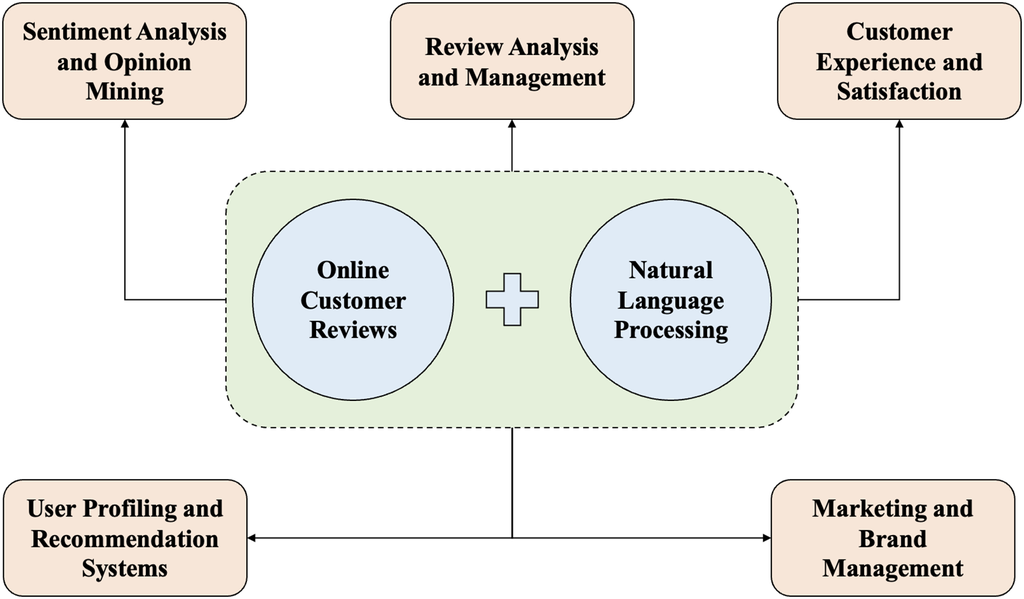

*Figure 1: Taxonomy of applications of NLP in online customer reviews (Malik and Bilal (2024), fig.1)*

Recent advances in transfer learning have made it easier to apply NLP in real-world scenarios. Pre-trained and fine-tuned NLP models available through open-source platforms, such as [Hugging Face](https://huggingface.co), allow the extraction of sentiment, emotion, and topic insights without requiring labelled datasets or training from scratch. This enables businesses to apply advanced language models directly to raw customer reviews, generating consistent, scalable insights even in data-rich, unlabelled environments. Their ability to process large and complex datasets facilitates accurate sentiment analysis, which can improve service quality, foster customer loyalty, and boost company revenue by up to 15% (Rahman and Maryani 2024).

## 1.2. Problem Statement

The project aims to analyse customer reviews from an e-commerce platform by examining their sentiment, emotional tone, and thematic framing to understand how these dimensions shape the overall customer experience by answering the following questions:

**Q1. Which sentiment, emotion, and topic-based features extracted from online customer reviews best explain variations in star ratings?**

**Q2. Which of these features contribute to distinguishing different types of customer feedback?**

By addressing these questions, we aim to generate actionable insights that enable businesses to enhance their product offerings and refine customer engagement strategies.

Although it has become very common to analyse customer reviews using generative LLMs such as ChatGPT, these approaches face challenges in stability and reproducibility, as outputs vary across sessions and API versions (Jang and Lukasiewicz 2023). By contrast, this project applies text classification models within a single Transformer-based framework, ensuring consistent, stable, and reproducible outputs across the dataset.

In this project, we use the *transformers* package in Python to extract features from unstructured review text, transforming it into structured variables suitable for regression and clustering. We then examine which features are most strongly associated with star ratings, identifying the key factors that explain customer satisfaction and dissatisfaction. Ultimately, we aim to uncover common patterns in customer feedback using unsupervised learning, thereby providing a more nuanced understanding of the diversity of customer experiences.

The analysis employs a combination of open-source programming tools. Python serves as the primary language for data pre-processing, feature extraction (*transformers*), regression (*statsmodels, sklearn*), and clustering (*umap*, *hdbscan*). R supports additional pre-processing, data visualisation, and statistical testing. Visualisations are created using *ggplot2*, *matplotlib*, *seaborn*, and *Tableau*, which collectively support exploratory analysis and clear presentation of results.

# 2. Data Analysis

## 2.1. Data Explanation

In this project, we use the grocery and gourmet food category of the large-scale [Amazon Reviews 2023](https://amazon-reviews-2023.github.io) dataset compiled by Hou et al. (2024). This category represents products with high consumer awareness, and interpreting reviews does not require specialist domain knowledge, making the findings broadly accessible and relevant.

Upon merging the grocery and gourmet food reviews with product metadata, a unified data frame contains more than 50,000 rows and 23 columns, including fields such as product images and descriptions.

The data cleaning process involves removing duplicate rows, handling missing values, and retaining only English-language reviews from verified purchases with a minimum length of ten words, thereby ensuring meaningful feedback. We also remove textual noise, such as excessive whitespace, HTML tags, and emojis.

Although transformer-based models used in this project for the feature extraction process raw text directly using their built-in tokenisers, we selectively apply traditional NLP pre-processing steps, such as stop-word removal and manual tokenisation, during exploratory analyses (e.g., n-grams and TF-IDF) to highlight distinctive vocabulary patterns across rating levels.

We standardise data types, convert star ratings to numeric values, and simplify field names for readability. Merging the review title and body into a single text field provides richer and more contextually complete inputs for NLP analysis. We then remove duplicate text from the title where it appears verbatim at the beginning of the body. Sentence count, derived from the merged reviews, serves as an indicator of review length and potential content richness, which can be associated with sentiment expression and feature extraction in subsequent analyses.

To achieve balanced representation across satisfaction levels, we draw a stratified random sample of 500 reviews for each star rating (on a five-point scale, where one represents strongly negative and five strongly positive). This approach satisfies the minimum sample size requirements for multiple correlation analysis (Green 1991).

The sampled dataset, comprising 2,500 reviews, retains five variables relevant to the project objectives: full review with title and body merged, number of sentences in the review, product title, retailer name, and star rating. Table 1 presents characteristics of the dataset used for exploratory analysis.

*Table 1: Overview of the stratified sample*

| **Field** | **Count** | **Count Distinct** | **Type** | **Explanation** |
| --- | --- | --- | --- | --- |
| Rating | 2500 | 5 | Numeric | Product rating on a five-star scale (1 = lowest, 5 = highest) |
| Review | 2500 | 2500 | Text | Review text comprising the title merged with the body |
| Sentence Count | 2500 | 37 | Numeric | Number of sentences in the merged review |
| Product Title | 2500 | 2200 | Text | Name of the reviewed product |
| Retailer | 2500 | 1399 | Text | Retailer or store associated with the product |

## 2.2. Exploratory Analysis

### 2.2.1. Data Overview

This balanced sampling produces a mean rating of 3.0 with a standard deviation of 1.41. The structure minimises bias towards positive or negative reviews and allows for more reliable comparisons of linguistic features across the satisfaction spectrum. Figure 2 and Figure 3 confirm that no single product or retailer dominates the dataset. The most frequent products and retailers each account for less than 3% of total reviews, ensuring diversity and reducing the risk of bias toward individual brands.

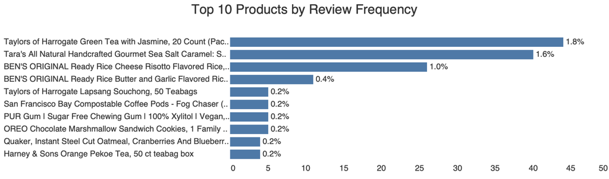

*Figure 2: 10 most reviewed products*

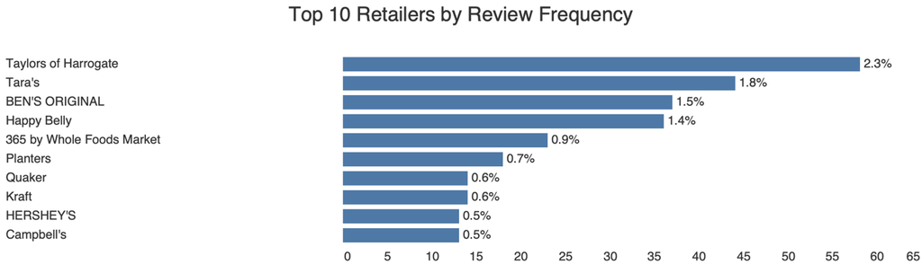

*Figure 3: 10 retailers with the largest review counts*

**Review Length Characteristics**

The distribution of review length, measured in sentence count, shows a highly skewed pattern (Figure 4). Most reviews are short, with the mode concentrated at two to five sentences. Counts decline sharply after ten sentences, and reviews longer than 20 sentences are rare. This long-tail distribution suggests that consumers typically provide concise feedback, while only a minority invest effort in writing substantially longer reviews.

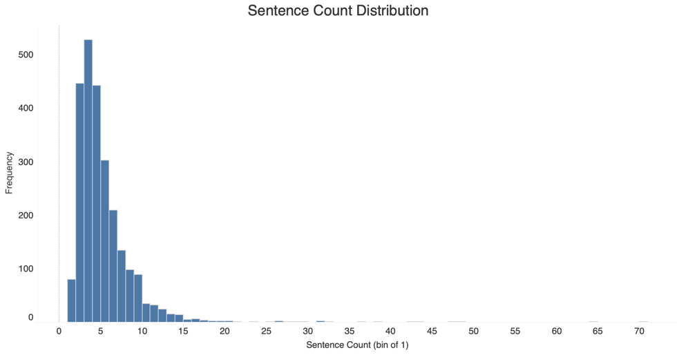

*Figure 4: Distribution of sentence counts*

Table 2 presents summary statistics for sentence counts. These values confirm the skewed distribution, with a low median and mode but a much higher maximum driven by extreme outliers.

*Table 2: Summary statistics of review sentence counts*

| **mean** | **sd** | **mode** | **min** | **25%** | **50%** | **75%** | **max** | **range** | **skew** | **kurtosis** |
| --- | --- | --- | --- | --- | --- | --- | --- | --- | --- | --- |
| 4.86 | 4.08 | 3 | 1 | 3 | 4 | 6 | 70 | 69 | 6.02 | 65.17 |

Disaggregating review length by rating (Figure 5) shows that this pattern is consistent across categories. Median length remains low at three to five sentences, although each category contains outliers. Some reviews, particularly in the two-star and four-star groups, extend beyond 50 sentences. This indicates that moderately negative or moderately positive experiences sometimes prompt detailed narratives.

To complement the sentence-level analysis, review length is also measured in words (Figure 6). The distribution again shows a skew, with most reviews under 100 words and a long tail of very lengthy entries. Median lengths remain consistently low across ratings, but upper ranges are higher for three- and four-star reviews. Outliers exceeding 700 words appear in the mid-range categories, suggesting that more nuanced experiences tend to generate longer narratives. In contrast, extreme satisfaction or dissatisfaction is often expressed briefly.

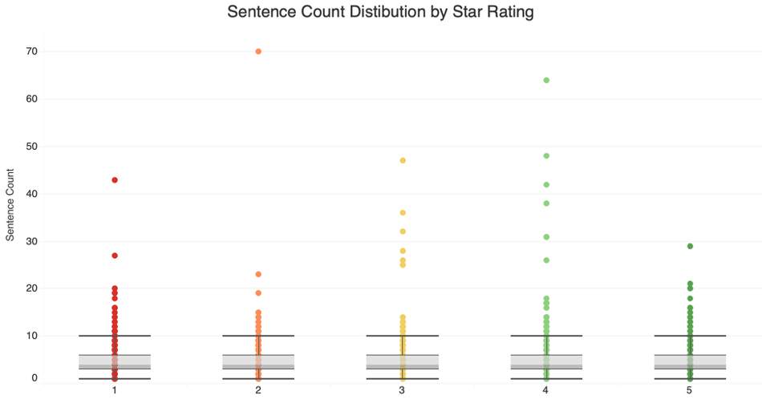

*Figure 5: Distribution of sentence counts by rating*

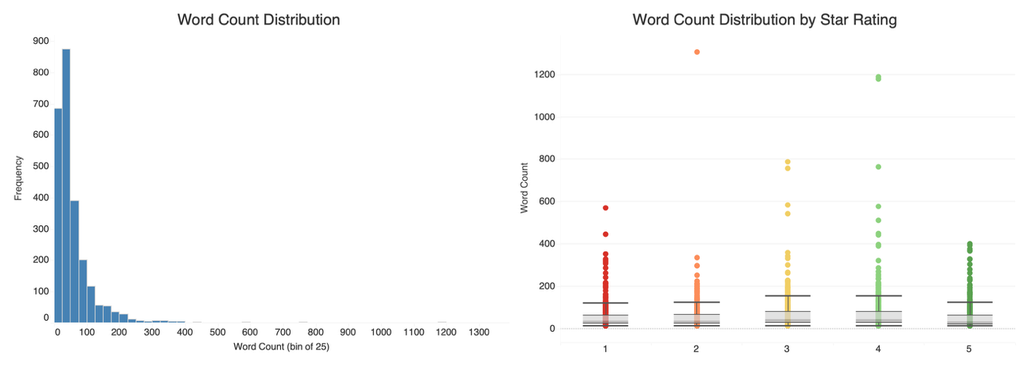

*Figure 6: Distributions of word counts*

The analysis of review length highlights two behavioural patterns. First, brevity is the norm across all ratings, with both highly positive and highly negative experiences often expressed in short statements. Second, although infrequent, longer reviews provide disproportionately rich qualitative insights. They appear most often in mid-range ratings, where feedback is more balanced and nuanced, and they may be especially valuable for identifying themes and opportunities for product improvement.

**Vocabulary Exploration**

We explore vocabulary and linguistic patterns across satisfaction levels to gain insight into the thematic structure of customer feedback. TF-IDF plots identify distinctive words associated with each rating, while the word cloud provides a visual overview of frequently used terms. Most frequent words, bigrams, and trigrams are also examined by rating, revealing common multi-word expressions and illustrating how language use varies across different satisfaction levels. Together, these exploratory techniques offer an initial view of thematic and stylistic variation before feature extraction.

The overall word cloud in Figure 7 highlights that the most frequent terms relate directly to the product experience. Words like *taste, flavor, good, bad, love,* *expensive*, and *price* dominate the lexicon, suggesting that evaluations are anchored in sensory quality, hedonic evaluation, and perceived value.

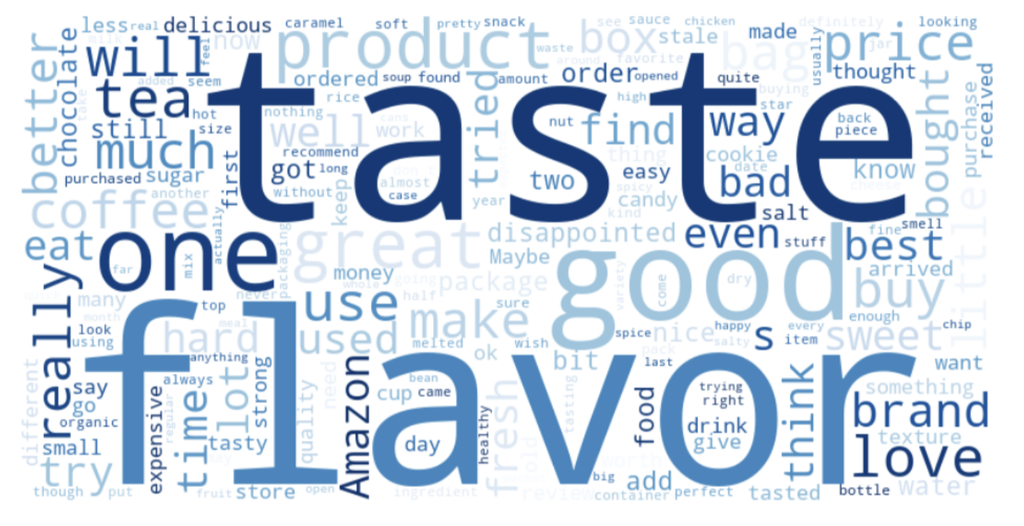

*Figure 7: Word cloud of most frequent terms in reviews*

```python
import pandas as pd
import pandas as pd
from wordcloud import WordCloud
import matplotlib.pyplot as plt

# Combine all reviews into one text
text = " ".join(df['Review'].dropna().astype(str))

# Generate the word cloud
wordcloud = WordCloud(
    width=800,
    height=400,
    background_color='white',
    colormap='Blues'
).generate(text)

# Display the word cloud
plt.figure(figsize=(10, 5))
plt.imshow(wordcloud, interpolation='bilinear')
plt.axis("off")
plt.tight_layout()
plt.show()
```

Figure 8 displays the most common words in reviews by rating, highlighting clear shifts in tone across satisfaction levels. Words like *taste*, *flavor*, and *product* appear across all ratings, but negative reviews (1–2 stars) are characterised by terms such as *disappointed*, *bad*, *bag*, and *box*, reflecting dissatisfaction and complaints. Mid-range reviews (3 stars) show a lexical mix, with both critical and positive terms like *bad* and *love*, indicating more neutral or ambivalent feedback. In contrast, four- and five-star reviews feature more positive language, including *love*, *delicious*, *nice*, and *price*, reinforcing the central role of quality, perceived value, and expectations in shaping customer sentiment.

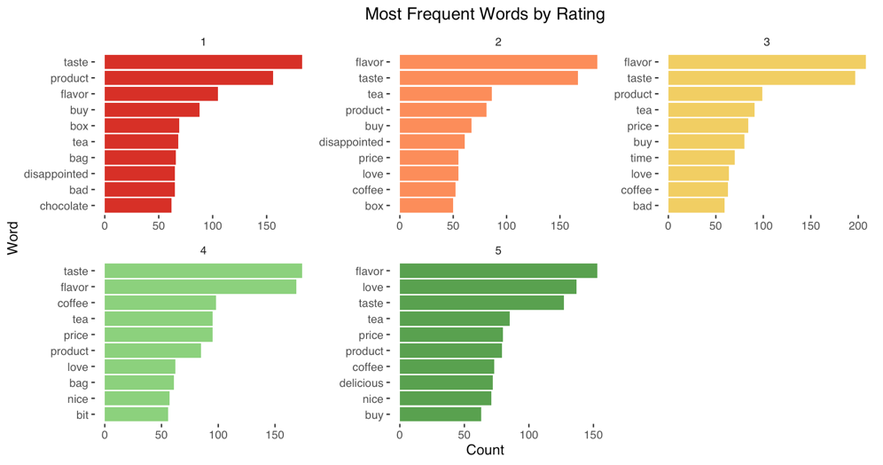

*Figure 8: Most frequent words by rating*

```r
library(ggplot2)
library(tidytext)
library(textclean)
library(stringr)

words <- df |>
  mutate(Review = replace_contraction(Review)) |>
  unnest_tokens(word, Review, token = "words") |>
  filter(!word %in% custom_stopwords$word,
         !str_detect(word, "^\\d+$"))

# Count top words per rating
top_words <- words |>
  count(Rating, word, sort = TRUE) |>
  group_by(Rating) |>
  slice_max(n, n = 10, with_ties = FALSE) |>
  ungroup()

# Plot words
ggplot(top_words, aes(x = reorder_within(word, n, Rating), y = n, fill = as.factor(Rating))) +
  geom_col(show.legend = FALSE) +
  facet_wrap(~Rating, scales = "free") +
  scale_x_reordered() +
  scale_fill_manual(values = rating_colours) +
  labs(title = "Most Frequent Words by Rating",
       x = "Word", y = "Count") +
  coord_flip() +
  theme_tufte(base_family = "Helvetica") +
  theme(
    plot.title = element_text(hjust = 0.5),
    legend.position = "none"
  )
```

The TF-IDF analysis by rating (Figure 9) further uncovers distinctive vocabulary. Negative reviews (1–2 stars) frequently use strongly emotive descriptors such as *rotten, disgusting,* or *awful,* alongside references to issues like *expiration date* or *stale.* Mid-range reviews (3 stars) contain more functional words, e.g., *repurchase*, reflecting a less polarised tone. Positive reviews (4–5 stars) often include specific product descriptors such as *cardamom, lactic, melon,* and terms with positive connotations such as *excellent.*

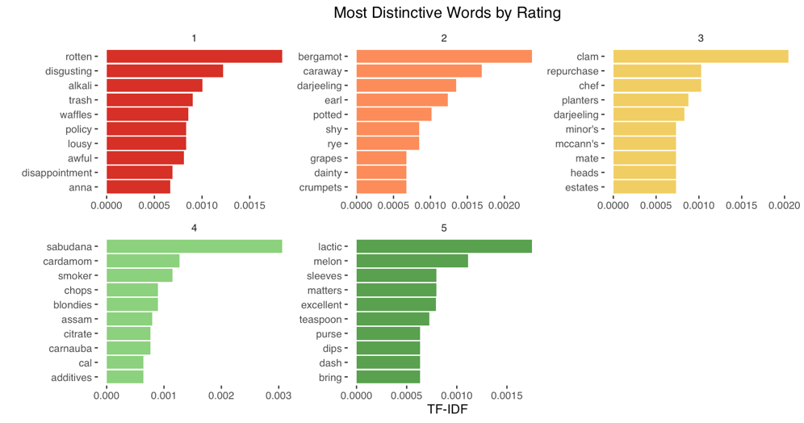

*Figure 9: Most distinctive words by rating (TF-IDF)*

```r
# Tokenise by word and clean
word_tokens <- df |>
  mutate(Review = replace_contraction(Review)) |>
  unnest_tokens(word, Review) |>
  anti_join(custom_stopwords, by = "word") |>
  filter(!str_detect(word, "^\\d+$"))  # remove pure numbers

# Most common words per rating
word_freq <- word_tokens |>
  count(Rating, word, sort = TRUE)

# Distinctive words using TF-IDF
word_tf_idf <- word_freq |>
  bind_tf_idf(term = word, document = Rating, n = n) |>
  group_by(Rating) |>
  slice_max(tf_idf, n = 10, with_ties = FALSE) |>
  ungroup()

# Plot TF-IDF words
ggplot(word_tf_idf, aes(x = reorder_within(word, tf_idf, Rating), y = tf_idf, fill = as.factor(Rating))) +
  geom_col(show.legend = FALSE) +
  facet_wrap(~Rating, scales = "free") +
  scale_x_reordered() +
  scale_fill_manual(values = rating_colours) +
  labs(title = "Most Distinctive Words by Rating",
       x = "", y = "TF-IDF") +
  coord_flip() +
  theme_tufte(base_family = "Helvetica") +
  theme(
    plot.title = element_text(hjust = 0.5),
    legend.position = "none"
  )
```

The analysis of bigrams (Figure 10) and trigrams (Figure 11) confirms these observations. Lower-rated reviews emphasise product faults through expressions such as *bad batch* and *didn’t taste fresh.* Higher-rated reviews include recommendation-oriented phrases like *perfect size, absolutely delicious,* and *coffee highly recommend.* This contrast suggests that dissatisfied customers highlight quality failures, whereas satisfied customers emphasise endorsement and product distinctiveness.

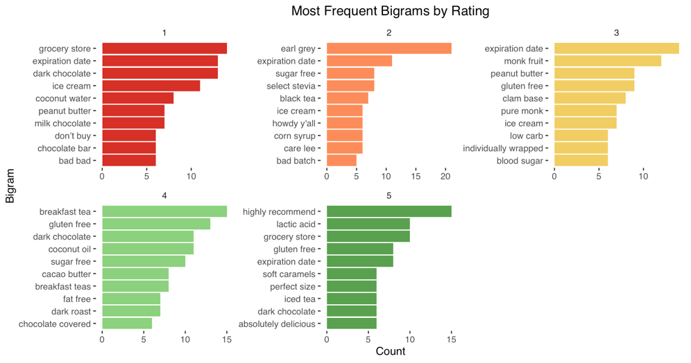

*Figure 10: Most frequent bigrams by rating*

```r
bigrams <- df |>
  mutate(Review = replace_contraction(Review)) |>
  unnest_tokens(bigram, Review, token = "ngrams", n = 2)

# Separate and remove stop words from bigrams
bigrams_separated <- bigrams |>
  separate(bigram, into = c("word1", "word2"), sep = " ") |>
  filter(!word1 %in% custom_stopwords$word,
         !word2 %in% custom_stopwords$word,
         !str_detect(word1, "^\\d+$"),
         !str_detect(word2, "^\\d+$")) |>
  unite(bigram, word1, word2, sep = " ")

# Count top bigrams per rating
top_bigrams <- bigrams_separated |>
  count(Rating, bigram, sort = TRUE) |>
  group_by(Rating) |>
  slice_max(n, n = 10, with_ties = FALSE) |>
  ungroup()

# Plot bigrams
ggplot(top_bigrams, aes(x = reorder_within(bigram, n, Rating), y = n, fill = as.factor(Rating))) +
  geom_col(show.legend = FALSE) +
  facet_wrap(~Rating, scales = "free") +
  scale_x_reordered() +
  scale_fill_manual(values = rating_colours) +
  labs(title = "Most Frequent Bigrams by Rating",
       x = "Bigram", y = "Count") +
  coord_flip() +
  theme_tufte(base_family = "Helvetica") +
  theme(
    plot.title = element_text(hjust = 0.5),
    legend.position = "none"
  )
```

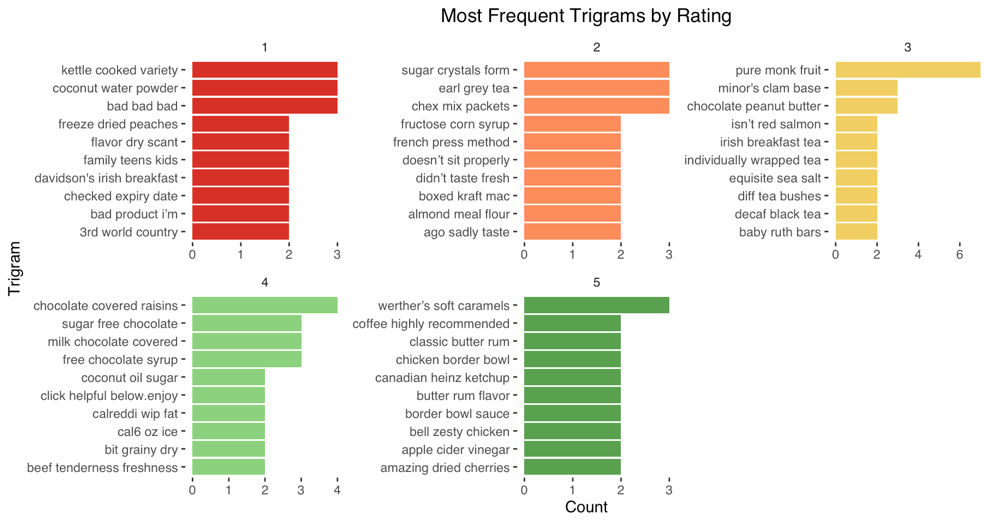

*Figure 11: Most frequent trigrams by rating*

```r
trigrams <- df |>
  mutate(Review = replace_contraction(Review)) |>
  unnest_tokens(trigram, Review, token = "ngrams", n = 3)

# Separate and remove stop words from trigrams
trigrams_separated <- trigrams |>
  separate(trigram, into = c("word1", "word2", "word3"), sep = " ") |>
  filter(
    !word1 %in% custom_stopwords$word,
    !word2 %in% custom_stopwords$word,
    !word3 %in% custom_stopwords$word,
    !str_detect(word1, "^\\d+$"),
    !str_detect(word2, "^\\d+$"),
    !str_detect(word3, "^\\d+$")
  ) |>
  unite(trigram, word1, word2, word3, sep = " ")

# Count top trigrams per rating
top_trigrams <- trigrams_separated |>
  count(Rating, trigram, sort = TRUE) |>
  group_by(Rating) |>
  slice_max(n, n = 10, with_ties = FALSE) |>
  ungroup()

# Plot trigrams
ggplot(top_trigrams, aes(x = reorder_within(trigram, n, Rating), y = n, fill = as.factor(Rating))) +
  geom_col(show.legend = FALSE) +
  facet_wrap(~Rating, scales = "free") +
  scale_x_reordered() +
  scale_fill_manual(values = rating_colours) +
  labs(title = "Most Frequent Trigrams by Rating",
       x = "Trigram", y = "Count") +
  coord_flip() +
  theme_tufte(base_family = "Helvetica") +
  theme(
    plot.title = element_text(hjust = 0.5),
    legend.position = "none"
  )
```

The vocabulary analysis also identifies terms that appear in both positive and negative contexts, most notably ’*expiration date’.* In negative reviews, the phrase refers to product defects such as *bad batch* or dissatisfaction with shelf life. In contrast, positive reviews use *expiration date* as reassurance of product quality and freshness. This dual use shows that certain attributes can act as both risk factors and differentiators: failure generates dissatisfaction, while meeting or exceeding expectations enhances positive evaluations. This finding highlights the importance of context-sensitive analysis, as identical terms may carry opposite meanings depending on the framing of the review.

Vocabulary exploration shows systematic variation in language across rating levels. Negative reviews use emotionally charged, problem-focused terms; mid-range reviews adopt a more neutral, descriptive tone; and positive reviews emphasise product qualities and endorsements. These findings support further analysis and provide linguistic cues that inform regression and clustering, where such terms act as predictive features of customer satisfaction.

This initial analysis confirms that the dataset provides a balanced foundation for further modelling. It combines coverage across rating levels with the diversity and noise typical of real-world reviews, making it suitable for examining how sentiment, emotion, and topic features vary across satisfaction levels, as well as for applying predictive and clustering techniques.

### 2.2.2 Sentiment Analysis

[*nlptown/bert-base-multilingual-uncased-sentiment*](https://huggingface.co/nlptown/bert-base-multilingual-uncased-sentiment), a model fine-tuned on product reviews for sentiment analysis, produces scores on a five-point scale. This granularity provides more nuanced insights than a three-class polarity classification, supporting personalised marketing and customer service strategies (Cherukuri 2024).

```python
from transformers import AutoTokenizer, AutoModelForSequenceClassification
import torch
import pandas as pd
import numpy as np

tokenizer = AutoTokenizer.from_pretrained("nlptown/bert-base-multilingual-uncased-sentiment")

model = AutoModelForSequenceClassification.from_pretrained("nlptown/bert-base-multilingual-uncased-sentiment")

def sentiment_score(text):
    tokens = tokenizer.encode(text, return_tensors='pt', truncation=True, padding=True)
    result = model(tokens)
    return int(torch.argmax(result.logits))+1

# Apply to dataframe
df['Sentiment Score'] = df['Review'].apply(sentiment_score)
```

The model’s outputs are compared with star ratings, used as proxy labels for ground-truth sentiment, to assess their alignment. The classification report in Table 3 shows an overall accuracy of 0.5680, indicating moderate alignment between predicted sentiment and user-assigned ratings. While this accuracy reflects the complexity of mapping free-text sentiment to discrete star ratings, it provides sufficient reliability to examine patterns and inconsistencies.

```python
from sklearn.metrics import accuracy_score, precision_recall_fscore_support, confusion_matrix, classification_report

y_true = df['Rating']
y_pred = df['Sentiment Score']

accuracy = accuracy_score(y_true, y_pred)

precision, recall, f1, _ = precision_recall_fscore_support(y_true, y_pred, labels=[1,2,3,4,5], average=None)

report = classification_report(y_true, y_pred, labels=[1,2,3,4,5])

# Accuracy
accuracy = accuracy_score(y_true, y_pred)

# Detailed metrics
precision, recall, f1, support = precision_recall_fscore_support(y_true, y_pred, labels=[1,2,3,4,5], average=None)

# Overall metrics
macro_precision, macro_recall, macro_f1, _ = precision_recall_fscore_support(y_true, y_pred, average='macro')

# Report
print(f"Accuracy: {accuracy:.4f}\n")

print("Precision, Recall, F1 by class:")
for i, label in enumerate([1, 2, 3, 4, 5]):
    print(f"{label} stars → Precision: {precision[i]:.4f}, Recall: {recall[i]:.4f}, F1: {f1[i]:.4f}")

print("\nOverall metrics:")
print(f"Macro  → Precision: {macro_precision:.4f}, Recall: {macro_recall:.4f}, F1: {macro_f1:.4f}")

print("\nConfusion Matrix:")
print(pd.DataFrame(conf_mat, index=[f"True {i}" for i in [1,2,3,4,5]], columns=[f"Pred {i}" for i in [1,2,3,4,5]]))

# Optional: print scikit-learn’s full classification report
print("\nClassification Report:")
print(classification_report(y_true, y_pred, labels=[1,2,3,4,5]))
```

*Table 3: Classification report of sentiment model performance with ratings as proxy labels*

| **Star Rating** | **Precision** | **Recall** | **F1-score** | **Support** |
| --- | --- | --- | --- | --- |
| 1 | 0.6257 | 0.6620 | 0.6433 | 500 |
| 2 | 0.4351 | 0.5300 | 0.4779 | 500 |
| 3 | 0.4957 | 0.4580 | 0.4761 | 500 |
| 4 | 0.5747 | 0.4540 | 0.5073 | 500 |
| 5 | 0.7287 | 0.7360 | 0.7323 | 500 |
| Accuracy | 0.5680 | 2500 |  |  |
| Macro avg | 0.5720 | 0.5680 | 0.5674 | 2500 |

Performance varies across classes. The model performs best on extreme ratings. Five-star reviews achieve the highest *F1*-score of 0.73, supported by both high precision (0.73) and recall (0.74). One-star reviews also perform reasonably well (*F1* = 0.64). Mid-range ratings are more difficult to classify. Two- and three-star reviews both score an *F1* of 0.48, suggesting the ambiguity and mixed sentiment typical of these reviews. The four-star category shows reduced recall (0.45), suggesting frequent misclassification into neighbouring classes.

The confusion matrix in Figure 12 highlights these tendencies. The one-star and five-star categories show strong diagonal concentration, while mid-range reviews display higher dispersion. Many four-star reviews are misclassified as five-star, and a large share of two-star reviews are misclassified as either one- or three-star. This pattern shows the “off-by-one” nature of most errors. When applying a tolerance of ±1 star, accuracy increases sharply to 0.928, suggesting that the model typically predicts the sentiment score within one category of the rating.

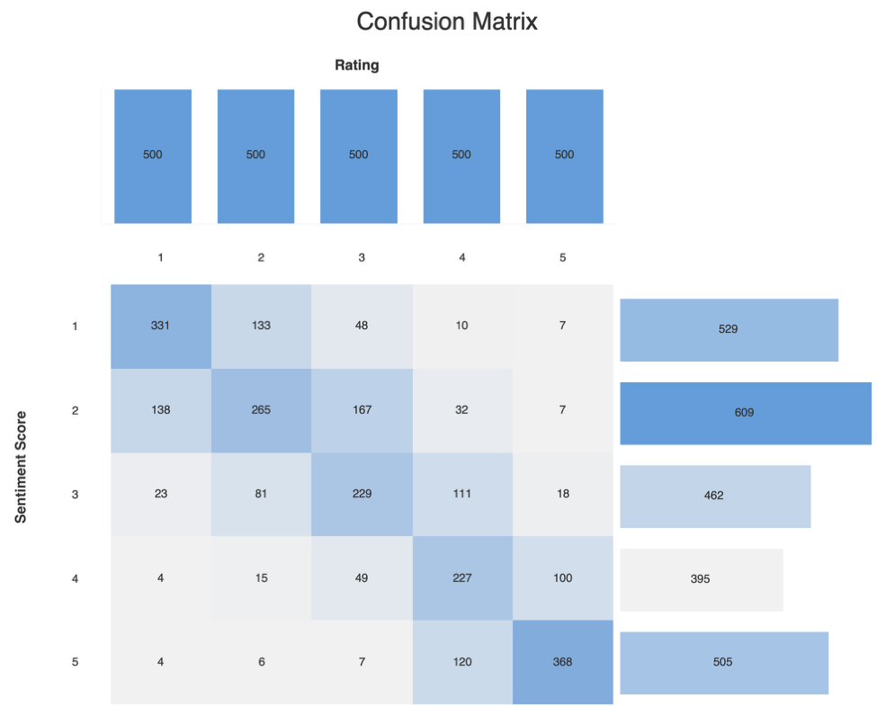

*Figure 12: Confusion matrix of predicted sentiment scores versus actual ratings*

```python
# Calculate off-by-one accuracy
off_by_one = np.abs(y_true - y_pred) <= 1
off_by_one_accuracy = np.mean(off_by_one)
```

Robustness checks confirm these results. Both the Wilcoxon signed-rank test (*p* < 0.001) and the chi-square test (*p* < 0.001) reject the null hypothesis of no association between predictions and ratings. The mean absolute error (*MAE*) of 0.52, compared to the *Rating* standard deviation of 1.41, indicates that prediction errors are small in magnitude. This is unsurprising given that user-generated ratings may not always reflect consistent or objective sentiment.

Figure 13 visualises individual review-level mismatches between *Sentiment Score* and *Rating*. While most reviews align closely, some show notable divergence, such as positive sentiment paired with low ratings or negative sentiment paired with high ratings. These cases may arise when textual content emphasises specific issues that do not drive the overall rating. They may also reflect sarcasm, rating biases, or the model’s failure to detect sentiment correctly.

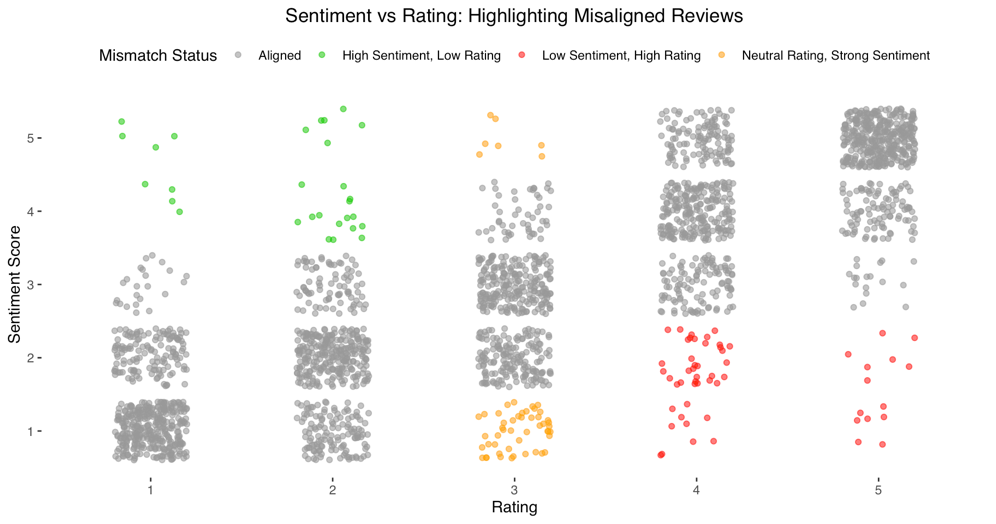

*Figure 13: Scatterplot of reviews with misaligned sentiment scores and star ratings*

```r
# Example thresholds for misalignment
threshold_positive <- 4   # unusually high sentiment for low rating
threshold_negative <- 3  # unusually low sentiment for high rating

misaligned_reviews <- df |>
  filter(
    (Rating <= 2 & `Sentiment Score` > threshold_positive) |
    (Rating >= 4 & `Sentiment Score` < threshold_negative)
  )


# Add mismatch classification
reviews_df <- df |>
  mutate(misaligned = case_when(
    Rating <= 2 & `Sentiment Score` >= threshold_positive ~ "High Sentiment, Low Rating",
    Rating >= 4 & `Sentiment Score` < threshold_negative ~ "Low Sentiment, High Rating",
    Rating == 3 & (`Sentiment Score` > 4 | `Sentiment Score` < 2) ~ "Neutral Rating, Strong Sentiment",
    TRUE ~ "Aligned"
  ))

# Visualise
ggplot(reviews_df, aes(x = factor(Rating), y = `Sentiment Score`, colour = misaligned)) +
  geom_jitter(width = 0.2, alpha = 0.6) +
  scale_colour_manual(values = c("High Sentiment, Low Rating" = "green3",
                                 "Low Sentiment, High Rating" ="red",
                                 "Neutral Rating, Strong Sentiment" = "orange",
                                 "Aligned" = "grey60")) +
  labs(x = "Rating", y = "Sentiment Score",
       title = "Sentiment vs Rating: Highlighting Misaligned Reviews",
       colour = "Mismatch Status") +
  theme_tufte(base_family = "Helvetica") +
  theme(
    plot.title = element_text(hjust = 0.5),
    legend.position = "top"
  )
```

Table 4 illustrates three examples of mismatches between *Rating* and *Sentiment Score*. In the first, a review describing shipping damage still carries a four-star rating. In the second, a sarcastic comment receives a low sentiment score despite a five-star rating. In the third, a positive review about ease of use is paired with a two-star rating, likely due to concerns about price. These examples highlight that ratings do not always align with expressed sentiment and that automated models struggle with sarcasm, contextual nuance, and value judgements.

```python
# Sample 10 random rows from mismatches

mismatches = df[
    ((df['Rating'] >= 4) & (df['Sentiment Score'] < 3)) |
    ((df['Rating'] <= 2) & (df['Sentiment Score'] > 4))
]
sampled = mismatches.sample(n=10, random_state=42)
```

*Table 4: Illustrative examples of rating-sentiment mismatches*

| **No.** | **Star Rating** | **Sentiment Score** | **Review** |
| --- | --- | --- | --- |
| 1 | 4 | 1 | “Exploded in shipping. Waited awhile for these… BUT I do not see a place to contact seller as two of the ginger ones (the ones I really wanted) exploded in my box.” |
| 2 | 5 | 1 | “Made a beautiful burger out of these. And my dumb brain didn’t even realize it was vegetarian.” |
| 3 | 2 | 5 | “Easy to use. Last year I brined a turkey with a home made brine. Had to boil water and the sugar and salt. Then wait for it to cool. It’s time consuming. This product is more expensive than making yo… |

Overall, the sentiment model demonstrates strong performance in identifying clear positive and negative extremes but weaker performance in mid-range categories. Despite these limitations, the off-by-one proximity indicates that the model provides a reliable basis for subsequent regression and clustering analyses.

### 2.2.3 Emotion Analysis

Emotion analysis complements sentiment classification by providing contextual insight into the linguistic and affective patterns in customer feedback. [*j-hartmann/emotion-english-distilroberta-base*](https://huggingface.co/j-hartmann/emotion-english-distilroberta-base) model generates continuous probability scores for Ekman’s six basic emotions, labelled by the model as joy (which Ekman (1992) refers to as enjoyment), anger, fear, disgust, sadness, and surprise, plus a neutral category. Each review’s emotional profile is represented by probabilities that sum to 1 across the seven categories, with the dominant emotion defined as the one with the highest probability. This probabilistic output captures the full range of variation in emotional signals, offering more nuanced insights and improving predictive and clustering performance (Dawson and Weiss 2012).

```python
from transformers import pipeline

classifier = pipeline(
    "text-classification",
    model="j-hartmann/emotion-english-distilroberta-base",
    top_k=None,
    truncation=True
)

# Store results
emotion_vectors = []
dominant_emotions = []

# Iterate through reviews
for review in df["Review"]:
    result = classifier(review)[0]  # list of dicts with 'label' and 'score'

    # Create a dict of label: score
    score_dict = {r["label"].capitalize(): r["score"] for r in result}

    # Store full score vector
    emotion_vectors.append(score_dict)

    # Store top emotion
    top_emotion = max(result, key=lambda x: x["score"])["label"].capitalize()
    dominant_emotions.append(top_emotion)

# Convert score vectors into a dataframe
emotion_scores_df = pd.DataFrame(emotion_vectors)

# Add the dominant emotion
emotion_scores_df["Dominant Emotion"] = dominant_emotions

# Concatenate with the original dataframe
df = pd.concat([df, emotion_scores_df], axis=1)
```

The distribution in Figure 14 shows that most reviews are classified as *Neutral*, followed by *Disgust* and *Joy*. *Anger* and *Fear* appear less frequently, suggesting that dissatisfaction is often expressed through milder emotions rather than strong negative affect.

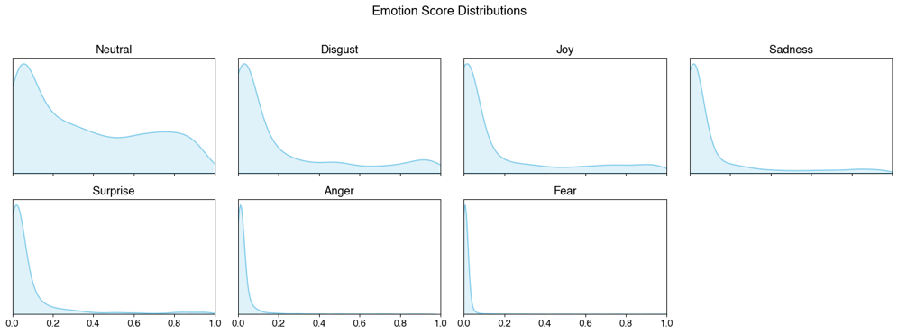

*Figure 14: Distribution of emotion probabilities across reviews*

```python
# Define emotion columns
emotion_columns = ["Disgust", "Neutral", "Surprise", "Sadness", "Anger", "Fear", "Joy"]

# Subset and drop NaNs
df_emotions = df[emotion_columns].dropna()

# Sort emotions by mean score
emotions_sorted = df_emotions.mean().sort_values(ascending=False).index.tolist()

# Set up grid layout
n_cols = 4
n_rows = int(np.ceil(len(emotions_sorted) / n_cols))
fig, axes = plt.subplots(n_rows, n_cols, figsize=(16, 3 * n_rows), sharex=True, sharey=False)
axes = axes.flatten()

# Plot each emotion
for i, emotion in enumerate(emotions_sorted):
    sns.kdeplot(data=df_emotions[emotion], ax=axes[i], fill=True, color="skyblue", linewidth=1.5)
    axes[i].set_title(emotion)
    axes[i].set_xlim(0, 1)
    axes[i].set_yticks([])  # Hide y-axis for cleaner look
    axes[i].set_xlabel("")
    axes[i].set_ylabel("")

# Turn off unused axes
for j in range(i + 1, len(axes)):
    axes[j].axis('off')

fig.suptitle("Emotion Score Distributions", fontsize=16)
plt.tight_layout(rect=[0, 0, 1, 0.96])
plt.show()
```

Figure 15 illustrates a clear alignment between dominant emotional tone and satisfaction: *Joy* is associated with higher ratings, while *Disgust*, *Sadness*, *Anger*, and *Fear* are more prevalent in lower ratings. *Neutral* and *Surprise* occur across all satisfaction levels.

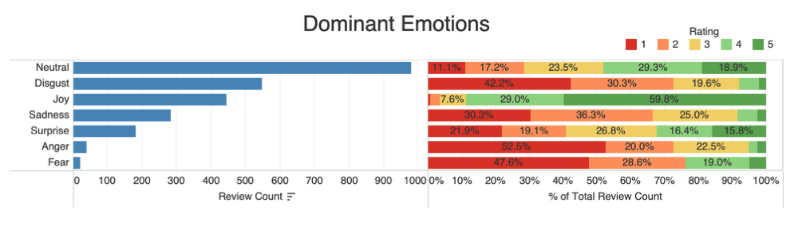

*Figure 15: Dominant emotions and their distribution by rating*

A chi-squared test confirms a statistically significant association between dominant emotion and sentiment score (*χ²* = 1381.44, *p* < 0.001). The effect size, measured by Cramér’s *V* (0.369), indicates a relatively strong relationship between emotion categories and sentiment scores, supporting the model’s validity in capturing meaningful emotional signals.

Qualitative inspection further illustrates the role of emotions. Review No.1 in Table 5 shows that neutrality in emotion does not necessarily imply neutrality in judgement. Although the text lacks strong affective language, it reflects dissatisfaction with product quantity despite a high rating. Review No.2 demonstrates that emotion detection can sometimes outperform sentiment scoring by correctly capturing dissatisfaction in cases where sentiment predictions are misleading.

```python
# Sample 10 random rows from mismatches

mismatches = df[
    ((df['Rating'] >= 4) & (df['Sentiment Score'] < 3)) |
    ((df['Rating'] <= 2) & (df['Sentiment Score'] > 4))
]
sampled = mismatches.sample(n=10, random_state=42)
```

*Table 5: Illustrative examples of rating-sentiment-emotion mismatches*

| **No.** | **Star Rating** | **Sentiment Score** | **Emotion** | **Review** |
| --- | --- | --- | --- | --- |
| 1 | 5 | 1 | Neutral | “Quantity not what I ordered. The order I placed was for a pack of 6 jars. The box contained only one 13 oz jar.” |
| 2 | 1 | 5 | Disgust | “Tastes like bubble gum with a hint of tropical flavor… These taste like classic bubble gum (yuck)… whereas the Tropical Beat actually tastes like what I would expect.” |

These examples highlight that neither model is flawless, yet emotion detection may capture nuances overlooked by sentiment scores. It is particularly effective in cases involving mixed evaluations, contextual phrasing, or subtle dissatisfaction. Together, sentiment and emotion analysis provide complementary perspectives that enrich the interpretation of customer feedback.

### 2.2.4 Topic Analysis

Topic analysis provides insights into the aspects linked to customer satisfaction and dissatisfaction. Topic classification enhances the interpretability of sentiment and emotion signals by situating them within relevant semantic categories and linking them to specific areas of customer experience. The use of pre-trained Natural Language Inference (NLI) models as zero-shot classifiers enables text classification into predefined categories without requiring task-specific training data. These models are especially valuable in business contexts, as they allow organisations to define custom taxonomies aligned with their operational needs. This contextual anchoring ensures that sentiments are not assessed in isolation but within the business dimensions to which they relate. We define candidate topic labels using insights from the background review and text mining techniques, including TF-IDF, frequent bigrams, trigrams, and word clouds. These include: *Not as Expected*, *Taste and Flavour*, *Price*, *Value for Money*, *Damaged*, *Quality*, *Freshness*, *Returns*, *Ingredients*, *Delivery*, *Size and Quantity*, *Packaging*, *Easy to Use*, and *Expiration Date*. This approach ensures that topics are both conceptually relevant and empirically grounded in the dataset. We apply zero-shot classification with the NLI model [*facebook/bart-large-mnli*](https://huggingface.co/facebook/bart-large-mnli) to assign probability scores to each topic for each review using a multi-label classification approach, assuming reviews may cover multiple aspects.

```python
from transformers import pipeline

# My candidate labels
candidate_labels = ['Packaging', 'Price', 'Value for Money', 'Taste and Flavour', 'Freshness', 'Expiration Date', 'Delivery', 'Ingredients', 'Quality', 'Size and Quantity', 'Easy to Use', 'Not as Expected', 'Returns', 'Damaged']

# Load the zero-shot classifier
classifier = pipeline("zero-shot-classification", model="facebook/bart-large-mnli")

# Function to classify a single piece of text and return a dict of scores
def classify_review(text):
    result = classifier(text, candidate_labels, multi_label=True)
    return {label: score for label, score in zip(result['labels'], result['scores'])}

# Apply the classification to each review
scores_df = df['Review'].apply(classify_review).apply(pd.Series)

# Concatenate the original df with the scores
df = pd.concat([df, scores_df], axis=1)

# Find dominant topic and its score
dominant_topic = scores_df.idxmax(axis=1)
dominant_score = scores_df.max(axis=1)

# Apply threshold: if score < threshold, assign 'Other'
df['Dominant Topic'] = dominant_topic.where(dominant_score >= 0.5, 'Other')
```

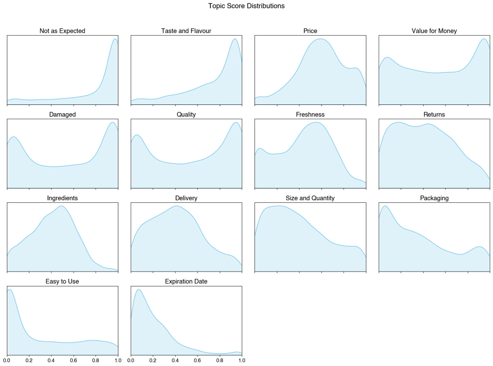

*Figure 16: Distribution of topic probabilities across reviews*

```python
# Define emotion columns
topic_columns = ['Packaging', 'Price', 'Value for Money', 'Taste and Flavour',
    'Freshness', 'Expiration Date', 'Delivery', 'Ingredients', 'Quality',
    'Size and Quantity', 'Easy to Use', 'Not as Expected', 'Returns', 'Damaged'
]

# Subset and drop NaNs
df_topics = df[topic_columns].dropna()

# Sort emotions by mean score
topics_sorted = df_topics.mean().sort_values(ascending=False).index.tolist()

# Set up grid layout
n_cols = 4
n_rows = int(np.ceil(len(topics_sorted) / n_cols))
fig, axes = plt.subplots(n_rows, n_cols, figsize=(16, 3 * n_rows), sharex=True, sharey=False)
axes = axes.flatten()

# Plot each emotion
for i, topic in enumerate(topics_sorted):
    sns.kdeplot(data=df_topics[topic], ax=axes[i], fill=True, color="skyblue", linewidth=1.5)
    axes[i].set_title(topic)
    axes[i].set_xlim(0, 1)
    axes[i].set_yticks([])  # Hide y-axis for cleaner look
    axes[i].set_xlabel("")
    axes[i].set_ylabel("")

# Turn off unused axes
for j in range(i + 1, len(axes)):
    axes[j].axis('off')

fig.suptitle("Topic Score Distributions", fontsize=16)
plt.tight_layout(rect=[0, 0, 1, 0.96])
plt.show()
```

The analysis of dominant topics, defined as the label with the highest probability (Figure 17), highlights *Not as Expected* as the single most frequent feature, appearing in more than one-third of all reviews. Although this topic spans all ratings, it is concentrated in one- to three-star reviews, underscoring unmet expectations as a leading cause of dissatisfaction. Other negative attributes include *Damaged* and *Returns*, both of which are heavily concentrated in low ratings, with more than half of the *Damaged* reviews assigned a one-star rating. By contrast, *Quality*, *Taste and Flavour*, and *Value for Money* are more evenly distributed, with higher representation in four- and five-star reviews, suggesting that meeting or exceeding these expectations contributes to satisfaction. Less frequent dominant topics also provide meaningful insights. *Freshness* is most often associated with higher ratings, while *Expiration Date* is more frequently linked to critical reviews. Only nine reviews fall into the *Other* residual group, where all topic probabilities are below 0.5, indicating that the identified topics capture most of the review content and provide clear insights into the factors that shape satisfaction and dissatisfaction.

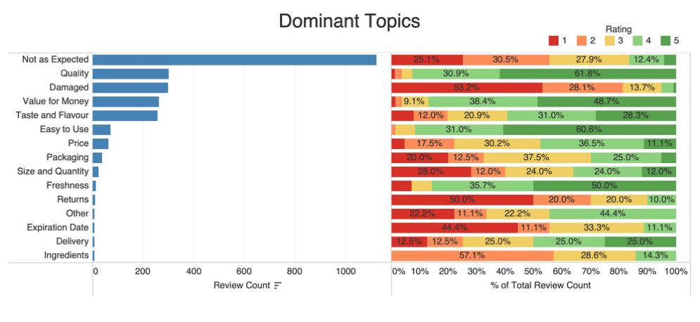

*Figure 17: Dominant topics and their distribution by rating*

### 2.2.5 Analysis of Dominant Topic–Emotion Combinations

The analysis of dominant topic-emotion combinations provides an integrated view of how customer concerns and emotional responses interact to shape evaluations. By mapping these combinations against mean sentiment scores and star ratings, Figure 18 identifies not only which topics are associated with satisfaction or dissatisfaction but also how emotions mediate these effects. The quadrant structure highlights alignment and misalignment between predicted sentiment and assigned ratings, offering insights that would not emerge from analysing topics, emotions, or sentiment independently. Bubble size further contextualises the prevalence of each combination, helping to prioritise issues by both impact and frequency. This integrated approach strengthens the interpretability of customer feedback and supports targeted, evidence-based decision-making. Clear patterns emerge across the four quadrants.

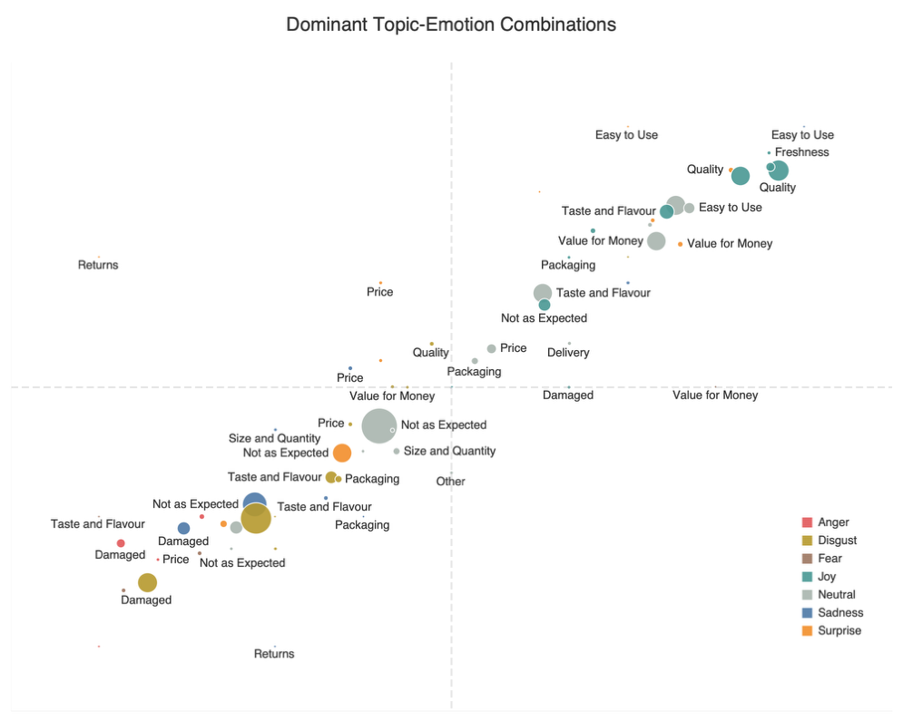

*Figure 18: Dominant topic-emotion combinations by mean sentiment score and rating*

In the high sentiment and high rating quadrant, combinations such as *Quality + Joy*, *Easy to Use + Sadness*, and *Value for Money + Neutral* dominate. These reflect positive experiences where emotional tone aligns with the evaluation. In this context, *Sadness* may signal effort or relief rather than dissatisfaction.

In the low sentiment and low rating quadrant, combinations such as *Damaged + Disgust*, *Returns + Sadness*, and *Not as Expected + Fear* appear. These represent emotionally charged complaints, with *Disgust* strongly associated with product failure and low satisfaction, confirming its role as a marker of intense negative feedback.

The low sentiment and high rating quadrant is sparsely populated. It includes combinations such as *Returns + Surprise*, suggesting that some reviewers award generous star ratings despite neutral or mixed emotional tones, possibly due to brand loyalty or isolated issues.

The high sentiment and low rating quadrant contains rare or anomalous combinations, such as *Damaged + Joy*. These may represent sarcasm, mixed signals, or model misclassification.

Overall, the analysis shows that topic–emotion combinations shape the alignment between sentiment and rating. *Joy*, combined with *Quality*, signals satisfaction, while *Disgust*, combined with condition-related topics, reliably indicates dissatisfaction. Topics such as *Not as Expected* and *Returns* recur across emotional tones, highlighting their broad relevance to customer perception.

Collectively, these findings demonstrate that customer satisfaction is associated with both functional reliability and sensory and value-based qualities, underscoring the multidimensional nature of consumer evaluations.

### 2.2.6 Correlation Analysis

After examining how sentiment, emotions, and topics interact to shape customer evaluations, correlation analysis establishes the internal coherence of the feature set and explores how the extracted features relate both to one another and to star ratings. Table A1 in Appendix 1 summarises all variables retained for further analysis, while the feature correlation matrix in Figure 19 presents their interrelationships. Statistical significance is indicated by asterisks at the levels of *p* < 0.05 (*), *p* < 0.01 (**), and *p* < 0.001 (***).

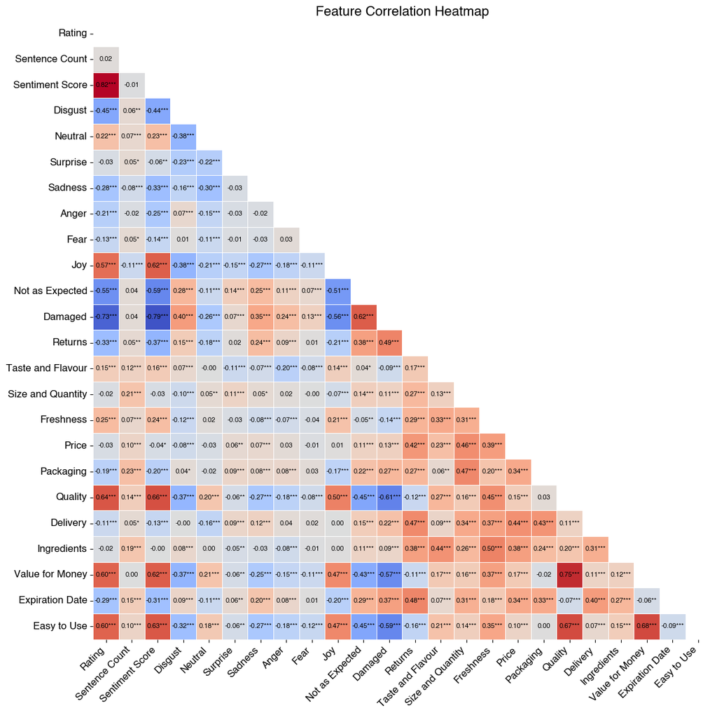

*Figure 19: Correlation matrix of features*

```python
import seaborn as sns
import matplotlib.pyplot as plt
from scipy.stats import pearsonr

df = pd.read_csv("reviews_final.csv")

# Drop unnecessary columns for regression (IDs, titles)
df_numeric = df.select_dtypes(include='number')
df_numeric = df_numeric.drop(columns=['Word Count'])

# Function to compute p-values matrix
def calculate_pvalues(df):
    pvalues = pd.DataFrame(np.ones((df.shape[1], df.shape[1])), columns=df.columns, index=df.columns)
    for i in range(df.shape[1]):
        for j in range(i+1, df.shape[1]):
            _, p = pearsonr(df.iloc[:, i], df.iloc[:, j])
            pvalues.iloc[i, j] = p
            pvalues.iloc[j, i] = p
    return pvalues

# Calculate correlation and p-values
corr = df_numeric.corr()
pvals = calculate_pvalues(df_numeric)

# Format annotations with asterisks
def format_corr_with_asterisks(corr, pvals):
    annot = corr.copy().astype(str)
    for i in range(corr.shape[0]):
        for j in range(corr.shape[1]):
            r = corr.iloc[i, j]
            p = pvals.iloc[i, j]
            if p < 0.001:
                annot.iloc[i, j] = f"{r:.2f}***"
            elif p < 0.01:
                annot.iloc[i, j] = f"{r:.2f}**"
            elif p < 0.05:
                annot.iloc[i, j] = f"{r:.2f}*"
            else:
                annot.iloc[i, j] = f"{r:.2f}"
    return annot

annot = format_corr_with_asterisks(corr, pvals)

plt.rcParams["font.family"] = "Helvetica"

# Mask the lower triangle
mask = np.triu(np.ones_like(corr, dtype=bool))

# Plot
plt.figure(figsize=(14, 12))
sns.heatmap(
    corr,
    mask=mask,
    cmap='coolwarm',
    center=0,
    annot=annot,
    fmt="",
    linewidths=0.4,
    square=True,
    cbar=False,
    annot_kws={"size": 8, "color": "black"}
)

plt.title("Feature Correlation Heatmap", fontsize=16)
plt.xticks(rotation=45, ha='right', fontsize=12)
plt.yticks(fontsize=12)
plt.tight_layout()
plt.show()
```

As expected**,** *Rating* correlates strongly and positively with *Sentiment Score* (*r* = 0.82, *p* < 0.001), confirming alignment between the user-assigned evaluations and the predicted sentiment. Among the emotions, *Joy* correlates positively with *Rating* (*r* = 0.57, *p* < 0.001), while *Disgust* correlates negatively with it (*r* = –0.45, *p* < 0.001). *Neutral* shows a weaker but significant positive correlation with *Rating* (*r* = 0.22, *p* < 0.001), consistent with its prevalence in less polarised reviews.

Topic features also show meaningful patterns. Negative themes such as *Damaged* (*r* = –0.73, *p* < 0.001) and *Not as Expected* (*r* = –0.55, *p* < 0.001) display strong negative correlations with star ratings. In contrast, *Value for Money* (*r* = 0.60, *p* < 0.001), *Easy to Use* (*r* = 0.60, *p* < 0.001), and *Quality* (r = 0.64, *p* < 0.001) correlate positively, indicating their role as factors significantly associated with satisfaction. *Taste and Flavour* shows only a modest correlation (*r* = 0.15, *p* < 0.001), suggesting that sensory descriptions occur across both positive and negative reviews and do not, by themselves, determine satisfaction.

*Sentence Count* is weakly correlated with ratings (*r* = 0.02) and is not statistically significant, confirming earlier observations that review length is not a primary determinant of satisfaction.

Beyond their associations with ratings, several internal relationships are evident among the extracted features. *Sentiment Score* correlates positively with *Joy* (*r* = 0.62, *p* < 0.001) and negatively with *Disgust* (*r* = –0.44, *p* < 0.001), *Damaged* (*r* = –0.79, *p* < 0.001), and *Not as Expected* (*r* = –0.59, *p* < 0.001), indicating that the sentiment model aligns with emotion and topic signals. *Damaged* correlates positively with *Returns* (*r* = 0.49, *p* < 0.001) and *Not as Expected* (*r* = 0.62, *p* < 0.001), and negatively with *Quality* (*r* = –0.61, *p* < 0.001), *Value for Money* (*r* = –0.57, *p* < 0.001), and *Easy to Use* (*r* = –0.59, *p* < 0.001). These associations show that product condition issues often overlap with dissatisfaction about expectations, quality, and returns. *Quality* correlates positively with *Value for Money* (*r* = 0.75, *p* < 0.001) and *Easy to Use* (*r* = 0.67, *p* < 0.001), reflecting that these attributes complement each other in shaping positive evaluations.

These results highlight the internal coherence of the feature set. Predicted sentiment aligns with star ratings, emotions align with sentiment polarity, and topics cluster into groups reflecting satisfaction (*quality*, *freshness*, *value for money*) or dissatisfaction (*damaged*, *returns*, *not as expected*). This structure provides a strong conceptual basis for including these features in subsequent regression analysis.

## 2.3. Regression Analysis

This project employs Ordinary Least Squares (OLS) regression to examine the relationship between extracted features and customer satisfaction. OLS regression offers simplicity and interpretability, making it a common method in data analysis. The dataset is split into training (80%) and testing (20%) subsets to assess the model’s generalisability.

Because emotion probabilities are compositional and sum to 1, including all categories in regression introduces perfect multicollinearity. To address this, we omit *Neutral* and treat it as the baseline. The remaining coefficients are therefore interpreted as deviations from a neutral state (Suits 1957).

```python
from sklearn.linear_model import LassoCV
from sklearn.preprocessing import StandardScaler
from sklearn.model_selection import train_test_split
import statsmodels.api as sm

X = df_numeric.drop(columns=['Rating', 'Neutral'])
y = df_numeric['Rating']

X_train, X_test, y_train, y_test = train_test_split(
    X, y, test_size=0.2, random_state=42
)
```

To enable meaningful comparison of effect sizes across predictors measured on different scales, we standardise all independent variables as z-scores. The reported coefficients then represent the expected change in customer rating associated with a one-standard-deviation increase in the predictor, holding all other variables constant. This standardisation supports clearer interpretation of the relative importance of predictors.

The OLS regression model (Figure 20) explains a substantial proportion of the variation in star ratings, with an *R²* of 0.717 and an adjusted *R²* of 0.714. This indicates that approximately 71% of the variance in ratings is accounted for by the predictors. The close alignment of *R²* and adjusted *R²* suggests that the relatively large set of predictors (22 variables, excluding *Neutral* to address multicollinearity) does not result in excessive overfitting and that most predictors contribute meaningfully to the model.

```python
scaler = StandardScaler()
X_train_scaled = scaler.fit_transform(X_train)
X_test_scaled = scaler.transform(X_test)

# Recreate dataframes with matching index from y_train / y_test
X_train_scaled_df = pd.DataFrame(X_train_scaled, columns=X_train.columns, index=y_train.index)
X_test_scaled_df = pd.DataFrame(X_test_scaled, columns=X_test.columns, index=y_test.index)

# Add constant for intercept
X_train_scaled_const = sm.add_constant(X_train_scaled_df)
X_test_scaled_const = sm.add_constant(X_test_scaled_df)

# Fit OLS on standardized training data
model_std = sm.OLS(y_train, X_train_scaled_const).fit()

# Predict on standardized test data
y_pred_std = model_std.predict(X_test_scaled_const)

# Print summary

model_std_robust = model_std.get_robustcov_results(cov_type='HC3')

print(model_std_robust.summary())
```

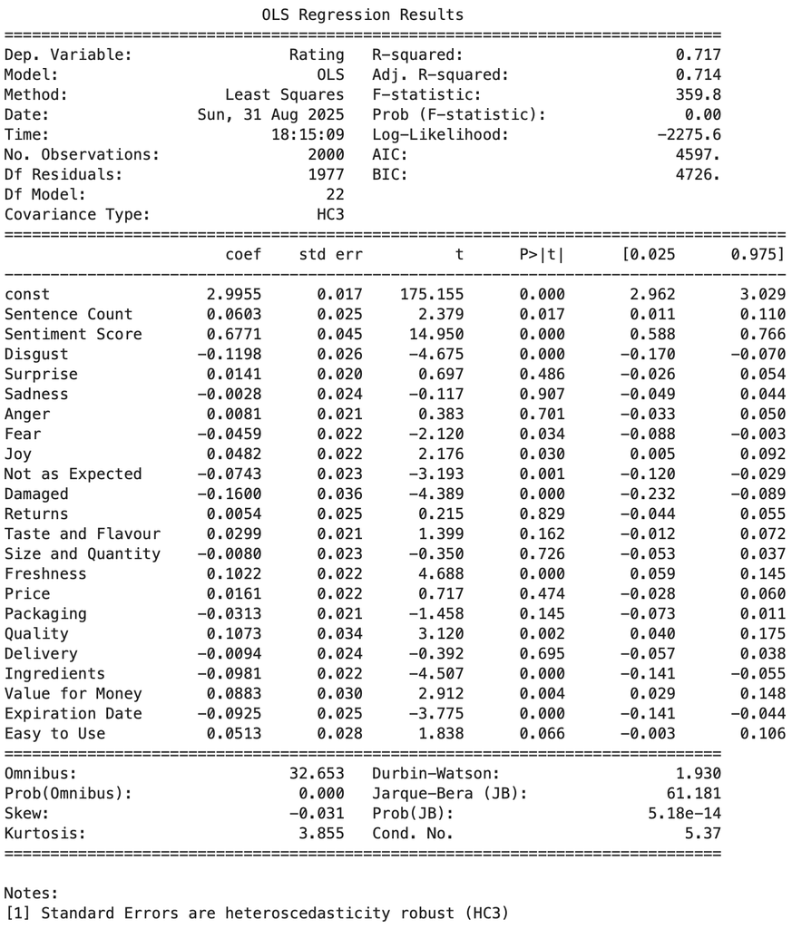

*Figure 20: Regression model summary with standardised coefficients*

The overall model fit is statistically significant (*F* (22, 1977) = 359.8, *p* < 0.001). On the test set, the model shows similar performance (*MSE* = 0.583, *RMSE* = 0.763, *R²* = 0.700), indicating that it generalises well beyond the training sample. While the Random Forest regressor with 100 estimators achieved slightly higher predictive accuracy **(***MSE* = 0.556, *RMSE* = 0.745, *R²* = 0.714), the OLS model offers greater interpretability, allowing for clear identification of feature-level effects and their relative importance.

Interaction terms were evaluated for inclusion in the regression model because they can capture complex feature relationships. However, to maintain simplicity and clarity, we retain the baseline model for better interpretability and statistical validity.

The regression analysis focuses on standardised coefficients to allow direct comparison of predictor importance. For completeness, Figure A1 in Appendix 2 provides the regression summary with non-standardised coefficients. These represent the expected change in *Rating* for a one-unit change in each predictor in its original scale. Including both sets of coefficients ensures transparency: the standardised results facilitate comparison across predictors, while the non-standardised values allow real-world interpretation.

### 2.3.1 Model Diagnostics

The regression diagnostics indicate broad consistency with the key assumptions of linear regression. The Durbin–Watson statistic (1.93) shows no evidence of autocorrelation, and the condition number (5.37) suggests that multicollinearity is not a concern. Variance inflation factors (VIFs) in Figure 21 confirm this finding: the highest values are observed for *Damaged* (3.93), *Sentiment Score* (3.83), and *Quality* (3.34), all of which are well below the conservative threshold of 5. These results indicate that multicollinearity among predictors does not compromise coefficient stability.

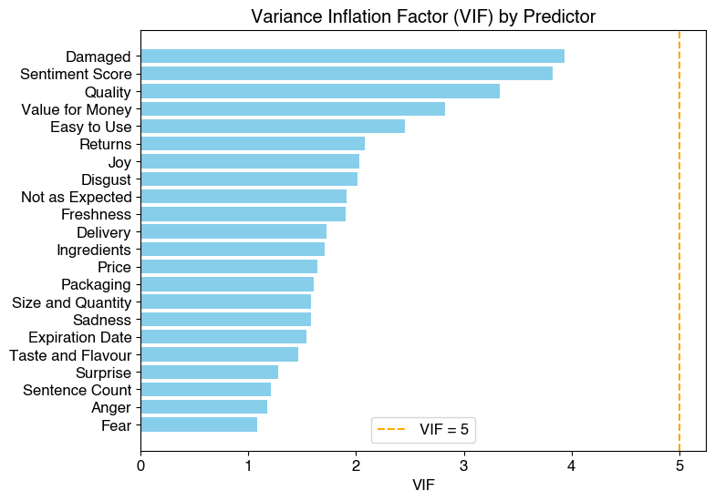

*Figure 21: Variance Inflation Factor (VIF) of predictors*

```python
import matplotlib.pyplot as plt
import numpy as np
plt.rcParams["font.family"] = "Helvetica"
plt.rcParams["font.size"] = 12

# Drop the constant
vif_df_no_const = vif_df[vif_df["Variable"] != "const"]

# Sort for readability
vif_df_sorted = vif_df_no_const.sort_values("VIF", ascending=True)

# Assign colours based on thresholds
colours = np.where(vif_df_sorted["VIF"] > 10, "red",
           np.where(vif_df_sorted["VIF"] > 5, "orange", "skyblue"))

plt.figure(figsize=(8, 6))
plt.barh(vif_df_sorted["Variable"], vif_df_sorted["VIF"], color=colours)
plt.axvline(x=5, color="orange", linestyle="--", label="VIF = 5")
#plt.axvline(x=10, color="red", linestyle="--", label="VIF = 10")
plt.xlabel("VIF")
plt.ylabel("")
plt.title("Variance Inflation Factor (VIF) by Predictor")
plt.legend()
plt.show()
```

The Jarque–Bera test is significant (*p* < 0.001), indicating some deviation from normality in the residuals. However, skewness is close to zero and kurtosis (3.85) indicate only mild leptokurtosis. Residual diagnostics (Figure A2 and Figure A3 in Appendix 3) confirm that residuals are approximately normally distributed, with only minor deviations in the tails. Given the large training sample size (*n* = 2,000), these departures are unlikely to bias estimates. Heteroscedasticity is present, as indicated by the Breusch–Pagan test (*LM* = 82.40, *p* < 0.001; *F* = 3.86, *p* < 0.001), but it is addressed through HC3 heteroscedasticity-robust standard errors, ensuring valid inference.

The diagnostic checks confirm that the assumptions of linear regression are sufficiently satisfied, supporting a reliable interpretation of the model results.

### 2.3.2 Key Predictors of Rating

The regression results indicate that sentiment, emotions, and topic-specific attributes collectively exhibit a significant association with ratings. Standardised coefficients in Figure 22 identify the strongest predictors.

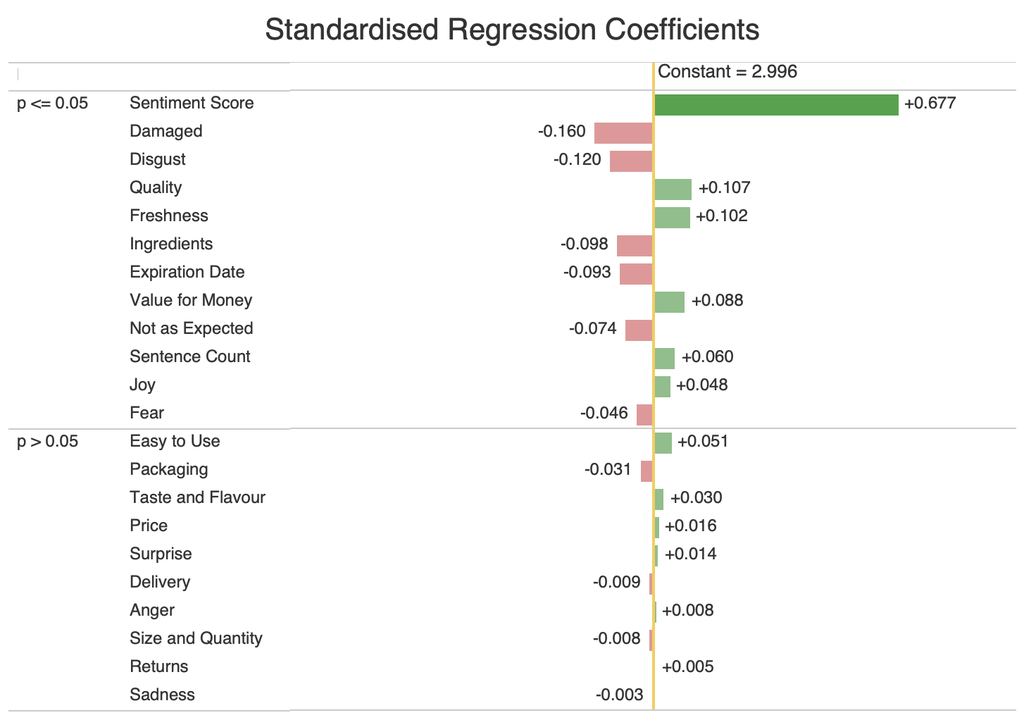

*Figure 22: Standardised regression coefficients for rating predictors*

The *Sentiment Score* emerges as the dominant predictor, with a relatively large positive coefficient (*β* = 0.677, *p* < 0.001), indicating that the overall tone of reviews is more strongly associated with ratings than any individual attribute. Positive features, such as *Freshness* (*β* = 0.102, p < 0.001), *Quality* (*β* = 0.107, *p* = 0.002), and *Value for Money* (*β* = 0.088, *p* = 0.004), are also positively associated with higher ratings, albeit with more modest effects.

Negative experiences exert stronger effects. Mentions of *Damaged* items (*β* = –0.160, *p* < 0.001), *Expiration Date* concerns (*β* = –0.093, *p* < 0.001), and unmet expectations (*β* = –0.074, *p* = 0.001) are all strongly associated with lower ratings. Negative emotions, particularly *Disgust* (*β* = –0.120, *p* < 0.001) and *Fear* (*β* = –0.046, *p* = 0.034), also demonstrate decreasing effects. The greater magnitude of these negative coefficients underscores the asymmetry in customer evaluations, where product failures and negative emotions carry more weight than positive attributes.

Several predictors, including *Surprise*, *Sadness*, *Anger*, *Returns*, *Taste and Flavour*, *Size* and *Quantity*, *Price*, *Packaging*, *Delivery*, and *Ease* *of Use* are not statistically significant. This suggests that, once other factors are controlled for, these attributes do not exhibit an independent statistical association with ratings, although they may still be relevant in specific contexts or in interaction with other variables.

The intercept of approximately 3.0 represents the expected star rating for an average review with all predictors at their mean values, closely matching the sample mean of the dependent variable.

### 2.3.3 Marginal Effects of Predictors

Figure 23 illustrates the effect of each statistically significant predictor on ratings, holding other variables constant. *Sentiment Score*, *Freshness*, and *Value* *for* *Money* all show positive slopes, indicating that higher values consistently translate into higher ratings. *Damaged*, *Disgust*, *Fear*, and *Expiration* *Date* concerns display negative slopes, confirming that these factors systematically reduce ratings.

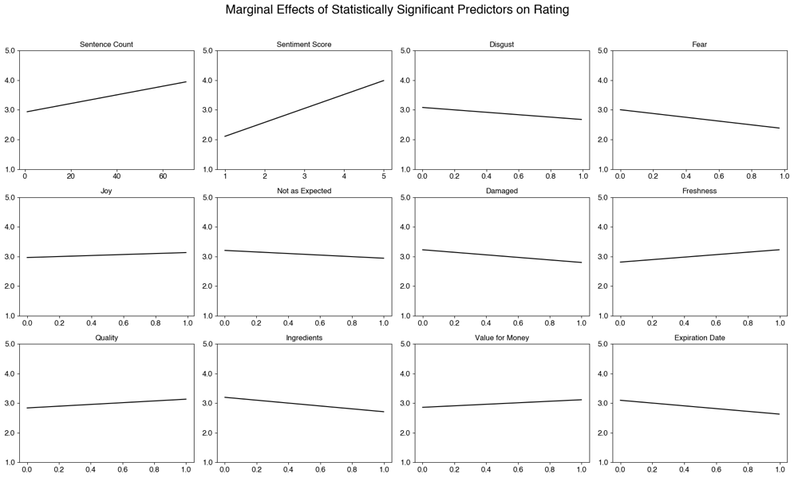

*Figure 23: Marginal effects of statistically significant predictors on rating*

```python
import numpy as np
import pandas as pd
import matplotlib.pyplot as plt
import statsmodels.api as sm


plt.rcParams["font.family"] = "Helvetica"
plt.rcParams["font.size"] = 12

# Get p-values from the fitted model
pvals = model.pvalues.drop("const", errors="ignore")  # drop intercept
alpha = 0.05  # significance threshold

# Keep only statistically significant predictors
significant_features = pvals[pvals < alpha].index.tolist()

# ---- MARGINAL PLOTS ----

# Configuration
n_cols = 4
selected = significant_features
n_rows = int(np.ceil(len(selected) / n_cols))

# Get mean row
X_avg = X_train.mean()

# Set up figure
fig, axes = plt.subplots(n_rows, n_cols, figsize=(4.5 * n_cols, 3.5 * n_rows), constrained_layout=True)
axes = axes.flatten()

# Define y-axis format and limits
y_min, y_max = 1, 5
y_ticks = np.linspace(y_min, y_max, 5)

# Loop over significant features
for i, var in enumerate(selected):
    # Create a range for this variable
    var_range = np.linspace(X_train[var].min(), X_train[var].max(), 100)

    # Create 100 copies of the average observation
    X_plot = pd.DataFrame([X_avg] * 100)
    X_plot[var] = var_range

    # Add constant manually
    X_plot.insert(0, 'const', 1)

    # Match column order with model input
    X_plot = X_plot[model.model.exog_names]

    # Predict ratings
    y_plot_pred = model.predict(X_plot)

    # Plot
    ax = axes[i]
    ax.plot(var_range, y_plot_pred, color='black')
    ax.set_title(f"{var}", fontsize=12)  # show p-value in title
    ax.set_xlabel('')
    ax.set_ylabel('')
    ax.grid(False)
    ax.set_ylim(y_min, y_max)
    ax.set_yticks(y_ticks)
    ax.set_yticklabels([f'{ytick:.1f}' for ytick in y_ticks])

# Remove unused axes
for j in range(len(selected), len(axes)):
    fig.delaxes(axes[j])

plt.suptitle('Marginal Effects of Statistically Significant Predictors on Rating', fontsize=20, y=1.02)
plt.tight_layout()
plt.show()
```

The differences in gradient are notable. The steep slope of the *Sentiment Score* reflects its strong association with evaluations. *Freshness* and *Value for Money* have more moderate positive slopes, suggesting incremental gains in satisfaction. By contrast, *Fear* and *Expiration Date* concerns show sharper negative slopes, reinforcing the conclusion that negative experiences exert stronger marginal effects than positive ones.

The regression results indicate that sentiment, emotions, and content-specific attributes are collectively associated with customer satisfaction. Sentiment serves as a broad evaluative signal, capturing the overall tone of reviews, while discrete emotions add explanatory value by reflecting the intensity and nature of customer reactions. Positive attributes and emotions contribute to incremental increases in ratings, whereas negative product experiences and adverse emotions exert disproportionately strong effects. This asymmetry underscores the importance of product reliability and quality control in maintaining satisfaction and minimising dissatisfaction.

## 2.4 Clustering Analysis

Unsupervised learning reveals patterns in customer feedback that do not emerge from regression or feature-by-feature analysis. Instead of focusing on how individual variables predict ratings, clustering analysis groups reviews based on their overall sentiment, emotion, and topic features. This approach helps identify natural customer experience profiles and helps understand how textual features distinguish different types of feedback.

By standardising numerical variables, excluding *Rating*, and reducing dimensionality using UMAP with two components, we maintain both local and global structures in high-dimensional data while supporting effective visualisation. The reduced feature set is then clustered with HDBSCAN, chosen for its ability to detect clusters of varying density and shape, handle noise points, and avoid the need to predefine the number of clusters.

We fine-tune HDBSCAN parameters using a grid search. The *min_cluster_size* parameter, which determines the minimum cluster size, ranges from 5 to 40 in increments of 5. The *min_samples* parameter, which defines how strictly points are classified as core or noise, ranges from 5 to 35 in increments of 5. From an exploratory perspective, the choice of cluster granularity depends on the analytical goals rather than solely on statistical stability metrics.

```python
import numpy as np
import pandas as pd
from sklearn.preprocessing import StandardScaler
from sklearn.metrics import silhouette_score
import umap
import hdbscan
from itertools import product
import warnings
import matplotlib.cm as cm
import matplotlib.colors as mcolors
warnings.filterwarnings("ignore", category=FutureWarning)
warnings.filterwarnings("ignore", category=UserWarning)

# Sample data – replace this with your own DataFrame
df = pd.read_csv("reviews_final.csv")  # Example
df_numeric = df.select_dtypes(include='number')
X = df_numeric.drop(columns=['Rating','Word Count'])


# Step 1: Standardise data
scaler = StandardScaler()
X_scaled = scaler.fit_transform(X)

# Step 2: UMAP dimensionality reduction
umap_model = umap.UMAP(n_components=2, random_state=42)
X_umap = umap_model.fit_transform(X_scaled)

# Step 3: Grid search over HDBSCAN parameters
min_cluster_sizes = [5, 10, 15, 20, 25, 30, 35, 40]
min_samples_list = [5, 10, 15, 20, 25, 30, 35]

results = []

for min_cluster_size, min_samples in product(min_cluster_sizes, min_samples_list):
    clusterer = hdbscan.HDBSCAN(min_cluster_size=min_cluster_size,
                                min_samples=min_samples,
                                prediction_data=True)
    labels = clusterer.fit_predict(X_umap)

    mask = labels != -1
    if len(set(labels[mask])) > 1:
        sil_score = silhouette_score(X_umap[mask], labels[mask])
    else:
        sil_score = -1  # Invalid silhouette (only one cluster or none)

    n_clusters = len(set(labels)) - (1 if -1 in labels else 0)
    noise_fraction = np.sum(labels == -1) / len(labels)

    results.append({
        'min_cluster_size': min_cluster_size,
        'min_samples': min_samples,
        'n_clusters': n_clusters,
        'silhouette_score': sil_score,
        'noise_fraction': noise_fraction
    })

# Convert results to DataFrame
results_df = pd.DataFrame(results)
results_df = results_df.sort_values(by='silhouette_score', ascending=False)

# Optional: visualise best result
best = results_df.iloc[0]
best_clusterer = hdbscan.HDBSCAN(min_cluster_size=int(best['min_cluster_size']),
                                 min_samples=int(best['min_samples']),
                                 prediction_data=True)
best_labels = best_clusterer.fit_predict(X_umap)
```

### 2.4.1 Cluster Structure

By using UMAP for dimensionality reduction and HDBSCAN for clustering, we select a configuration that prioritises interpretability and meaningful insights over statistical robustness among the alternatives generated by the grid search. The chosen settings require clusters to contain at least 35 reviews and apply a comparable threshold for density. This configuration identifies four distinct clusters (Figure 24), with 15.9% of reviews (*n* = 397) classified as noise (Cluster 0). Figure 25 shows that cluster sizes vary considerably. Cluster 4 is the largest, accounting for 51.6% of the reviews (*n* = 1,290), while Cluster 1 is the smallest, comprising only 5.9% (*n* = 147).

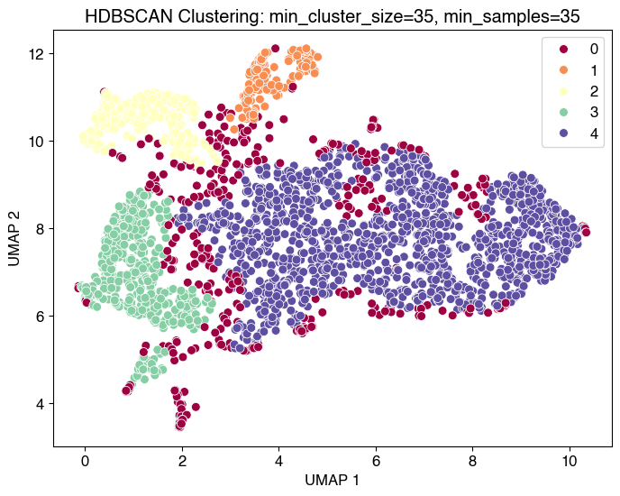

*Figure 24: UMAP projection of reviews clustered with HDBSCAN*

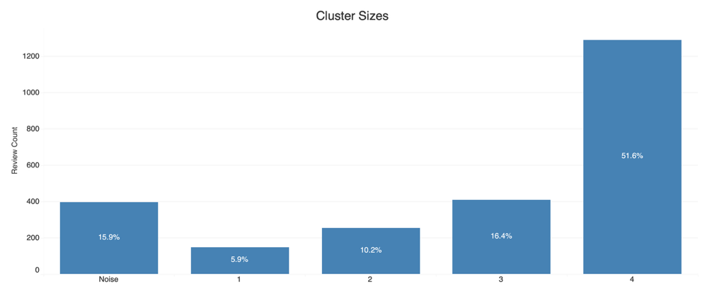

*Figure 25: Cluster sizes and proportion of reviews*

```python
# Assign cluster 48 parameters
cluster_48 = hdbscan.HDBSCAN(min_cluster_size=35,
                             min_samples=35,
                             prediction_data=True)

best_labels = cluster_48.fit_predict(X_umap)

# --- Relabel clusters: noise=0, clusters start from 1 ---
mask = best_labels != -1
new_labels = np.zeros_like(best_labels)
if mask.any():
    cluster_labels = np.unique(best_labels[mask])
    mapping = {old: new for new, old in enumerate(cluster_labels, start=1)}
    new_labels[mask] = [mapping[x] for x in best_labels[mask]]

# Visualise
plt.figure(figsize=(8, 6))
sns.scatterplot(x=X_umap[:, 0], y=X_umap[:, 1], hue=new_labels, palette="Spectral", s=50, legend='full')
plt.title(f"HDBSCAN Clustering: min_cluster_size=35, min_samples=35")
plt.xlabel("UMAP 1")
plt.ylabel("UMAP 2")
plt.show()
```

### 2.4.2 Cluster Diagnostics

Although the clustering structure shows moderate separation (silhouette score = 0.406) and meaningful between-cluster variance (Calinski–Harabasz Index = 1375.3), the Davies–Bouldin Index (0.59) further indicates relatively distinct clusters. Stability metrics, however, indicate considerable variability in individual assignments (ARI = 0.083 ± 0.022, Jaccard Index = 0.439), suggesting that cluster membership is not highly reproducible. Kruskal–Wallis tests confirm significant differences across clusters for most features after FDR correction (*p* < 0.05), supporting the interpretability of the results. *Joy*, *Disgust*, *Neutral*, *Sentiment Score*, and *Damaged* demonstrate strong affects (all *H* > 750, *p* < 0.001), as well as *Quality* (*H* = 538, *p* < 0.001), *Value for Money* (*H* = 507, *p* < 0.001), and negative or functional aspects such as *Not as Expected*, *Expiration Date*, and *Returns* (all *H* > 225, *p* < 0.001). *Ingredients* is the only feature without significant variation (*p* = 0.184). For completeness, Table A2 in Appendix 4 provides the Kruskal–Wallis H test results.

These results indicate that while individual cluster assignments should be treated cautiously, the overall structure is sufficiently consistent to identify broad patterns and profile customer feedback, rather than for rigid segmentation.

### 2.4.3 Cluster Characteristics

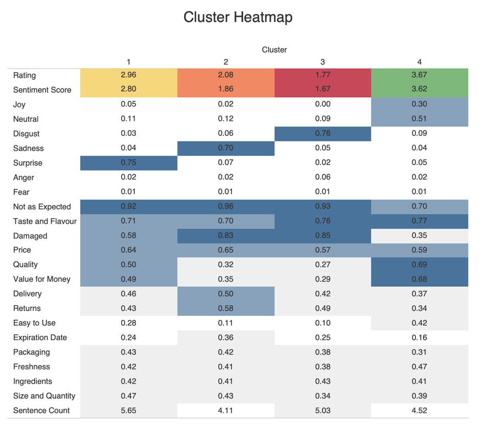

*Figure 26: Cluster characteristics based on mean feature values*

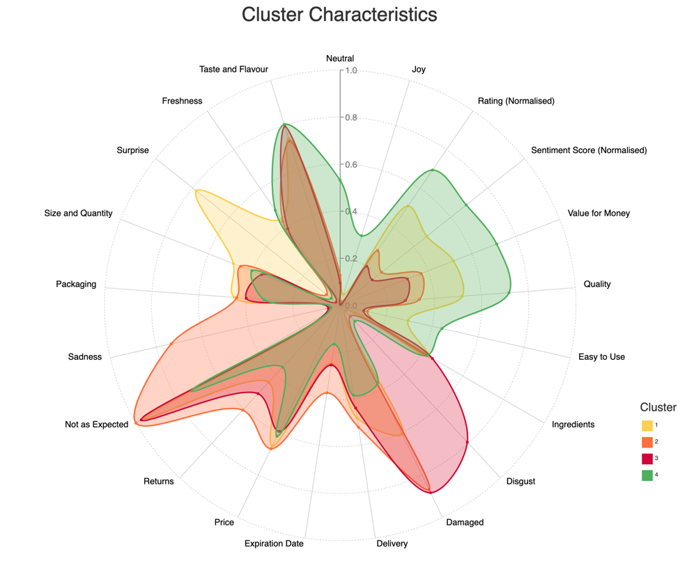

*Figure 27: Radar chart of cluster characteristics*

Cluster 2 (*n* = 255, mean *Rating* = 2.08) is strongly associated with negative topics, including *Damaged* (mean = 0.83), *Not* *as* *Expected* (mean = 0.96), *Returns* (mean = 0.58), *Delivery* (mean = 0.50), and *Expiration* *Date* (mean = 0.36). The mean *Sentiment Score* is low (1.86) but still correlates positively with *Rating* (*r* = 0.52, *p* < 0.001). *Sadness* dominates as the primary emotion (mean = 0.70) and displays a strong negative correlation with *Neutral* (*r* = -0.84, *p* < 0.001), showing that dissatisfaction with product condition and logistical problems plays a significant role in shaping the cluster.

Cluster 3 (*n* = 411, mean *Rating* = 1.77) has the lowest *Sentiment Score* (mean = 1.67). Reviews in this group focus heavily on *Damaged* items (mean = 0.85), unmet expectations (mean = 0.93), and *Taste and Flavour* (mean = 0.76). *Disgust* is the dominant emotion (mean = 0.76), and the correlation structure mirrors that of Cluster 2, though with even stronger negative associations between *Damaged* items and *Sentiment Score* (*r* = -0.61, *p* < 0.001). This suggests that negative reviews are highly likely to be emotionally intense and mention issues with product condition.

# 3. Key Insights and Implications

## 3.1 Key Findings

The exploratory analysis shows that shorter reviews are more frequent, while mid-range ratings tend to include longer and more detailed reviews. Vocabulary patterns highlight the role of taste, flavour, price, value, unmet expectations, and product condition issues, such as expired or damaged items, in distinguishing reviews across satisfaction levels.

The pre-trained transformer models successfully capture systematic variation in sentiment scores, emotional tones, and thematic content across rating levels. The classification report confirms that the sentiment model performs well at distinguishing between polarity (positive versus negative) but struggles with more nuanced evaluations. The analysis also reveals some inconsistencies: in some cases, the predicted sentiment or emotion diverges from the assigned star rating, particularly in reviews that contain sarcasm, irony, or positive language paired with low ratings. These findings reflect the complexity of subjective, user-generated content and demonstrate that implicit sentiment and mixed polarity present significant challenges for accurate classification.

The correlation analysis provides further insights into relationships between features. Sentiment scores are most strongly correlated with star ratings, while emotions such as disgust and joy, as well as several topic features, also show significant but more moderate associations. This confirms the multidimensional nature of the extracted features and their relevance for explaining variation in customer ratings.

The regression analysis demonstrates the predictive power of sentiment, emotion, and topic features, which collectively explain over 70% of the variation in ratings. The findings indicate that the sentiment score is the strongest overall predictor of star ratings, reaffirming its value in capturing evaluative tone. However, emotions and topics also contribute explanatory power, indicating that sentiment analysis alone does not capture the full complexity of customer feedback. Disgust and fear are associated with lower ratings, while joy best explains higher ratings. Disgust emerges as the most significant negative factor, consistent with prior findings that this emotion, along with sadness, strongly reduces consumer preference for food products (Motoki and Sugiura 2018). In contrast, reviews expressing joy are positively associated with higher ratings, signalling quality and satisfaction. Topic-level analysis reveals that negative product-related themes such as damaged items, unmet expectations, ingredients, and expiration dates predict lower ratings, underscoring the importance of quality control and effective return policies (Barutçu and Basak 2018). Conversely, aspects such as freshness, quality, and value for money are consistently associated with higher ratings, reinforcing their importance for customer satisfaction.

Clustering analysis supports these findings by identifying four distinct types of customer feedback. Emotional tone serves as the primary differentiator across clusters, with joy standing out as the most distinctive variable, while sadness dominates reviews in Cluster 2, though it is not a statistically significant predictor of star ratings. Dissatisfaction often arises from unmet expectations and product failures, consistent with expectation-disconfirmation theory, which suggests that satisfaction reflects the gap between expected and actual experiences (Park et al. 2021).

Cluster 2, “Disappointed by Product Condition,” includes reviews with lower mean ratings and expressions of sadness related to damaged items, returns, and delivery problems, consistent with previous evidence that logistical issues weaken future purchase intentions (Tolulope and Owoseni 2024). Although reviews expressing sadness often indicate dissatisfaction, they are seen as less helpful, as they may lack the emotional intensity needed to strongly resonate with other consumers (Ren and Hong 2019). This implies that while such reviews still signal reputational risk, their persuasive influence on future buyers might be weaker.

Cluster 3, “Emotionally Intense Complaints,” includes the most negative reviews, mainly characterised by disgust and associated with failures in taste, quality, and product integrity. It is well-documented that expressions of disgust diminish purchase intentions and trigger contagion effects across related products (Morales and Fitzsimons 2007), (Guido et al. 2018).

In contrast, Cluster 4, “Neutral to Joyful Experiences,” represents broadly satisfied customers, emphasising hedonic and functional features such as taste, value, freshness, and quality. This aligns with the concept of customer delight, where joy arises when experiences exceed expectations (Barnes and Krallman 2019).

While not a primary focus of the analysis, sentence count provides structural context for it. It shows a moderate positive association with ratings in regression analysis, but is relatively weak in clustering results. Longer reviews may reflect higher engagement or more complex experiences, but have limited predictive power compared to sentiment, emotions, and topics.

The exploratory analysis, regression, and clustering results confirm the multidimensional nature of customer satisfaction. Feedback varies systematically in sentiment, emotional tone, and thematic focus, underscoring the heterogeneity of consumer experiences and the value of integrated analysis.

## 3.2 Business Recommendations

The findings suggest several actionable strategies for enhancing the customer experience.

Expectation management is central to shaping satisfaction. The frequent occurrence of unmet expectations and their significant impact on ratings suggest that businesses should invest in clearer product descriptions and more accurate visual representations to minimise post-purchase disappointment.

Product condition and fulfilment emerge as critical vulnerabilities. Clusters 2 and 3 indicate that damaged products have a strong negative association with satisfaction. With quality ranking the second-strongest positive predictor of ratings, addressing these tangible issues can yield immediate improvements in customer experience.

Emotional intensity amplifies dissatisfaction. The prevalence of disgust in low-rated reviews, along with the negative association between fear and ratings, demonstrates that emotionally charged failures have lasting effects. Since disgust is one of the strongest negative predictors of ratings, businesses should prioritise these cases through rapid response systems, proactive customer service interventions, and compensation policies to mitigate reputational risks (Langaro et al. 2022).

Positive reinforcement also plays a key role. Attributes such as value for money, freshness, and quality are consistently linked to higher ratings and the group with the most positive reviews. Reinforcing these perceptions through transparent pricing, accurate product descriptions, and strong branding can strengthen satisfaction and encourage repeat purchases. In e-commerce, sales promotions and personalised shopping experiences have been shown to boost positive emotions, which in turn increase purchase intentions and consumer loyalty (Cuong 2024). Leveraging these strategies can foster customer satisfaction and drive long-term growth.

# Appendices

## Appendix 1. Summary Statistics

*Table A1: Summary statistics of the dataset*

|  | **vars** | **n** | **mean** | **sd** | **min** | **25%** | **50%** | **75%** | **max** | **skew** | **kurtosis** |
| --- | --- | --- | --- | --- | --- | --- | --- | --- | --- | --- | --- |
| Rating | 1 | 2500 | 3 | 1.41 | 1 | 2 | 3 | 4 | 5 | 0 | -1.3 |
| Sentence Count | 2 | 2500 | 4.86 | 4.08 | 1 | 3 | 4 | 6 | 70 | 6.02 | 65.17 |
| Sentiment Score | 3 | 2500 | 2.9 | 1.43 | 1 | 2 | 3 | 4 | 5 | 0.16 | -1.31 |
| Disgust | 4 | 2500 | 0.21 | 0.29 | 0 | 0.01 | 0.06 | 0.30 | 0.99 | 1.46 | 0.76 |
| Neutral | 5 | 2500 | 0.35 | 0.3 | 0 | 0.07 | 0.28 | 0.62 | 0.96 | 0.49 | -1.16 |
| Surprise | 6 | 2500 | 0.09 | 0.19 | 0 | 0.01 | 0.02 | 0.07 | 0.98 | 3.15 | 9.69 |
| Sadness | 7 | 2500 | 0.12 | 0.23 | 0 | 0.01 | 0.02 | 0.09 | 0.99 | 2.42 | 4.83 |
| Anger | 8 | 2500 | 0.03 | 0.08 | 0 | 0.01 | 0.01 | 0.02 | 0.92 | 6.23 | 46.4 |
| Fear | 9 | 2500 | 0.01 | 0.07 | 0 | 0.00 | 0.00 | 0.01 | 0.97 | 9.59 | 104.18 |
| Joy | 10 | 2500 | 0.18 | 0.28 | 0 | 0.00 | 0.02 | 0.22 | 0.99 | 1.62 | 1.2 |
| Not as Expected | 11 | 2500 | 0.8 | 0.28 | 0 | 0.70 | 0.95 | 0.99 | 1 | -1.5 | 1.01 |
| Damaged | 12 | 2500 | 0.54 | 0.37 | 0 | 0.14 | 0.59 | 0.93 | 1 | -0.15 | -1.59 |
| Returns | 13 | 2500 | 0.41 | 0.26 | 0 | 0.19 | 0.40 | 0.61 | 1 | 0.28 | -0.89 |
| Taste and Flavour | 14 | 2500 | 0.74 | 0.26 | 0 | 0.61 | 0.84 | 0.94 | 1 | -1.18 | 0.46 |
| Size and Quantity | 15 | 2500 | 0.4 | 0.27 | 0 | 0.17 | 0.35 | 0.58 | 0.99 | 0.5 | -0.76 |
| Freshness | 16 | 2500 | 0.44 | 0.25 | 0 | 0.24 | 0.46 | 0.62 | 1 | -0.13 | -0.81 |
| Price | 17 | 2500 | 0.59 | 0.22 | 0 | 0.46 | 0.60 | 0.75 | 1 | -0.34 | -0.22 |
| Packaging | 18 | 2500 | 0.36 | 0.31 | 0 | 0.09 | 0.29 | 0.58 | 1 | 0.61 | -0.88 |
| Quality | 19 | 2500 | 0.54 | 0.36 | 0 | 0.15 | 0.58 | 0.91 | 1 | -0.17 | -1.54 |
| Delivery | 20 | 2500 | 0.41 | 0.24 | 0 | 0.22 | 0.40 | 0.57 | 0.99 | 0.32 | -0.59 |
| Ingredients | 21 | 2500 | 0.41 | 0.2 | 0 | 0.27 | 0.42 | 0.55 | 1 | -0.03 | -0.46 |
| Value for Money | 22 | 2500 | 0.54 | 0.34 | 0 | 0.21 | 0.56 | 0.89 | 1 | -0.12 | -1.45 |
| Expiration Date | 23 | 2500 | 0.21 | 0.2 | 0 | 0.07 | 0.15 | 0.29 | 0.99 | 1.71 | 3.26 |
| Easy to Use | 24 | 2500 | 0.3 | 0.33 | 0 | 0.01 | 0.13 | 0.57 | 1 | 0.77 | -0.9 |

## Appendix 2. Non-Standardised Regression Model Summary

```python
X_train_sm = sm.add_constant(X_train)
model = sm.OLS(y_train, X_train_sm).fit()

X_test_sm = sm.add_constant(X_test)
y_pred = model.predict(X_test_sm)

model_robust = model.get_robustcov_results(cov_type='HC3')
print(model_robust.summary())
```

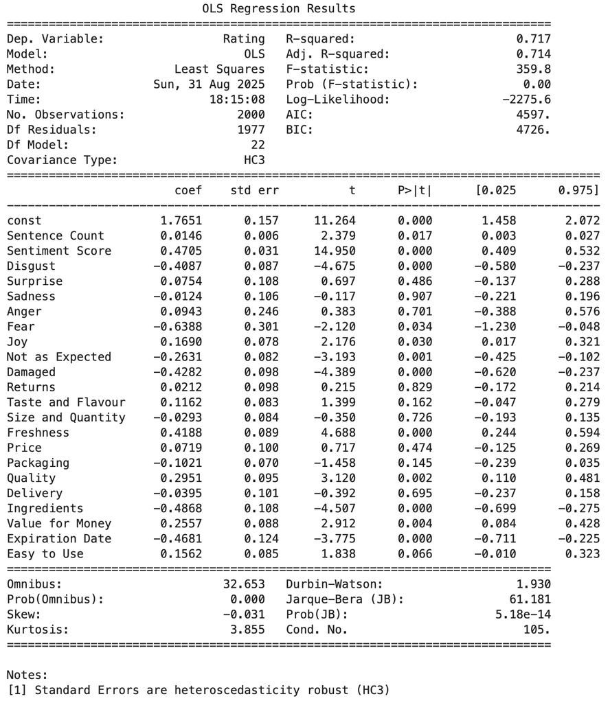

*Figure A1: Regression model summary with non-standardised coefficients*

## Appendix 3. Regression Model: Residuals Diagnostics

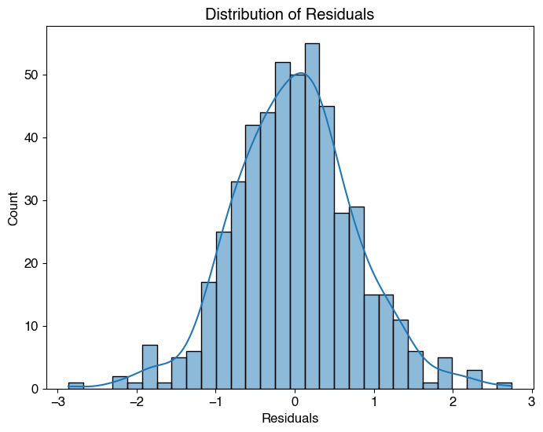

*Figure A2: Distribution of regression model residuals*

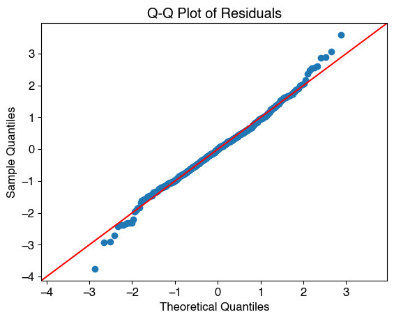

*Figure A3: Q-Q plot of regression model residuals*

```python
import matplotlib.pyplot as plt
import seaborn as sns
import statsmodels.api as sm

# Calculate residuals
residuals = y_test - y_pred_std

# Histogram of residuals
plt.figure(figsize=(8,6))
sns.histplot(residuals, kde=True, bins=30)
plt.xlabel("Residuals")
plt.title("Distribution of Residuals")
plt.show()


# Q-Q plot for normality check
sm.qqplot(residuals, line='45', fit=True)
plt.title("Q-Q Plot of Residuals")
plt.show()
```

## Appendix 4. Kruskal–Wallis H test results

*Table A2: Kruskal–Wallis H test results*

|  | **H Statistic** | **p-value** | **FDR-corrected p-value** |
| --- | --- | --- | --- |
| Joy | 1048.13 | 0.000 | 0.000 |
| Disgust | 975.54 | 0.000 | 0.000 |
| Neutral | 911.53 | 0.000 | 0.000 |
| Sentiment Score | 775.81 | 0.000 | 0.000 |
| Damaged | 766.10 | 0.000 | 0.000 |
| Sadness | 682.09 | 0.000 | 0.000 |
| Surprise | 674.30 | 0.000 | 0.000 |
| Quality | 538.11 | 0.000 | 0.000 |
| Value for Money | 507.00 | 0.000 | 0.000 |
| Fear | 468.50 | 0.000 | 0.000 |
| Not as Expected | 460.75 | 0.000 | 0.000 |
| Easy to Use | 455.00 | 0.000 | 0.000 |
| Expiration Date | 240.00 | 0.000 | 0.000 |
| Returns | 226.35 | 0.000 | 0.000 |
| Anger | 156.75 | 0.000 | 0.000 |
| Delivery | 79.97 | 0.000 | 0.000 |
| Packaging | 61.85 | 0.000 | 0.000 |
| Freshness | 43.74 | 0.000 | 0.000 |
| Size and Quantity | 33.93 | 0.000 | 0.000 |
| Price | 32.04 | 0.000 | 0.000 |
| Sentence Count | 28.68 | 0.000 | 0.000 |
| Taste and Flavour | 22.93 | 0.000 | 0.000 |
| Ingredients | 4.84 | 0.184 | 0.184 |